# ggplot2 学术绘图案例

pmgh

2025-11-16

# ggplot2 学术绘图案例

在这份笔记中，我将尝试用ggplot2复现自己在学术期刊、新闻报刊中看到的漂亮的数据可视化图，或是总结自己在科研过程中使用ggplot2学习到的画图技巧。所有内容都会以案例形式展示，并将持续更新。

注意：

1. 由于全部笔记都为案例形式，其中的画图技巧可能总结得不全面而且比较零散，因此仅供参考。
2. 所有案例数据都为公开数据或测试数据（无实际意义），仅供画图学习，本人不保证数据真实正确、所有数据也都不代表本人观点。
3. 如果同一问题有多个解决方案，标题中带有“★”的是最推荐的用法。
4. 如果对这些绘图案例有修改意见，欢迎交流讨论。
5. **文中未说明来源的代码均为原创，其余为收集整理，转载本文请注明来源**。

# 环境设定

```r
# 加载包
# 我更习惯使用data.table包，然而data.table包有很多函数与tidyverse冲突，因此同时加载时需注意是否同名函数被替换。

# 定义函数
# 1. 建立函数将R environment中的data.frame转为字符串，用于在文档中保存短小的数据（如案例5数据，注意数据量大时会报错）
texttable <- function(data){
  # 表格转文字格式的函数
  col.n <- ncol(data)
  col.name <- names(data)
  res <- "data <- data.frame("
  for(i in 1:col.n){
    val <- data[[i]]
    if(is.character(val)){
      tres <- paste0(col.name[i]," = c('", paste0(val, collapse = "', '"), "'), ")
    } else{
      tres <- paste0(col.name[i], " = c(", paste0(val, collapse = ", "), "), ")
    }
    res <- paste(res, tres)
  }
  # res <- str_remove(res,", $") %>%  paste0(")")
  res <- gsub(", $", "", res)
  res <- paste0(res, ")")
  return(res)
}
```

# 1. 显示数学符号和公式

ggplot2中，可以使用plotmath语法展示符号和公式，也可以利用第三方包，实现markdown或html等语法创建公式。

**（1）符号公式用法：**

1. 在可以设置`parse=T`的场景中，如`geom_text`, `annotate`等：使用满足plotmath语法的字符串，并设置`parse=T`，将字符串转为符号公式
2. 在没有`parse`参数的场景中，如`labs(x=..., y=...)`, `scale_x_continuous(labels=...)`：可利用`expression`、`parse`、`str2expression`等函数直接写公式符号，最推荐用`expression`
3. 在轴、图、分面等标题位置：可使用markdown语法实现简单字符，方法是用纯文本（满足markdown语法），加上theme中上指定精确位置的`ggtext::element_markdown`。注意：（1）此方法只能识别简单的html语法和符号，不支持latex公式，但可实现某些plotmath缺失的功能，比如带符号公式的换行（2）此方法只能用在标题位置，不能用于如`annotate`，`geom_text`等绘图区域内部，这种情况下可考虑`ggtext::geom_richtext`（3）在分面标题中，只能用此方法实现标题中的公式字符（如案例1.2），无法用`expression`
4. 在1、2场景中，都可用`latex2exp::TeX`，把满足latex语法的纯文本，转换为满足plotmath语法的字符型或公式型（利用`output`参数指定输出类型），当然这里latex功能并非完全支持，比如公式换行、字体颜色、字号就不支持

**（2）plotmath语法（与latex对比）：**

1. plotmath中，任何字符都默认为公式符号，纯文本需用单引号特别说明（latex中字符默认为纯文本，公式需用`$`特别说明）。例如：`expression(abscsdfwlaph)`和`expression('abscsdfwlaph')`虽然结果一样，但前者相当于公式中的变量，后者才是纯文本。
2. plotmath中，如不加单引号，则字母后可接数字，但是数字后不可直接为字母（latex中默认纯文本，则没有这种限制）。例如：`expression(abscsdfwlaph33)`没问题，但是`expression(33abscsdfwlaph)`会报错。
3. plotmath中，同一类字符会被识别为同一类符号的参数（latex需要用大括号说明作用范围）。例如：`expression(''^210*Pb[ex])`等同于`TeX("$^{210}Pb_{ex}$")`，其中，plotmath中，210都是上标，没必要用大括号说明，而latex中的210需要大括号指定，否则只有2是上标。
4. plotmath中，不同类别字符之间需要连接，连接方法包括无空格连接符`*`、函数`paste`和有空格连接符`~`，此外，一些符号前后必须有内容，如没有必须用空文本，如`^`前的`''`（latex中，没有这样的要求）。例如210pbex的几种表示方法：`expression(''^210*Pb[ex])`，`expression(paste(''^210,Pb[ex]))`，`TeX("$^{210}Pb_{ex}$")`

**（3）注意事项**

1. 关于公式换行。ggplot2中展示的所有公式，无论是字符型+`parse=T`的，还是用plotmath直接写的，或者是用latex转换来的，都只支持纯文本的换行，不支持包含公式的换行。例如`title=TeX("fasdfasd\nfadfadf")`和`title=expression("fasdfasd\nfadfadf")`都没问题，但`title=expression(''^210*Pb[ex]*'\n'*CO[2])`和`title=TeX("$^{210}Pb_ex$ \n $CO_2$")`，前者没换行，后者报错。如果是简单的符号换行，可以用markdown中的br标签换行，例如`title="CO<sub>2</sub><br><sup>210</sup>pb<sub>ex</sub>"`+`plot.title = ggtext::element_markdown()`。如果是在`annotate`或者`geom_text`中，则只能是在图层层面添加了
2. ggplot2的v4.0.0版本之后，在存在`parse=T`的场景中，如`geom_text`, `annotate`等，其中的`label`参数仅支持字符型，不能传递公式型了（此前warning，现在error）
3. ggplot2的v4.0.0版本之后，在一些位置使用markdown语法，需要精确指定，例如必须是`strip.text.y.left = element_markdown()`，不能是`strip.text = element_markdown()`
4. 不能在df中储存公式型，只能存为字符型，然后这样使用：`geom_text(aes(label=l), parse = T)`
5. 已经使用plotmath的位置，不能再用`element_markdown()`转换，否则又变回纯文本了

**（4）其他参考资料：**

1. 关于plotmath语法，详细帮助见`?plotmath`
2. [HTML数学公式](https://juejin.cn/post/6859985646079836174)
3. [公式手写识别与html代码生成](https://webdemo.myscript.com/views/math/index.html)
4. [Unicode字符代码](https://www.rapidtables.org/zh-CN/code/text/unicode-characters.html)
5. 其他可用符号，可参考[The Adobe Symbol Encoding](https://www.stat.auckland.ac.nz/~paul/R/CM/AdobeSym.html)

## 1.1 plotmath公式

使用字符型+`parse=T`将字符型转为公式型，或直接用expression生成公式型，或将latex字符转换为公式型。用额外包也可以简单使用markdown语法绘制符号公式，但不推荐。

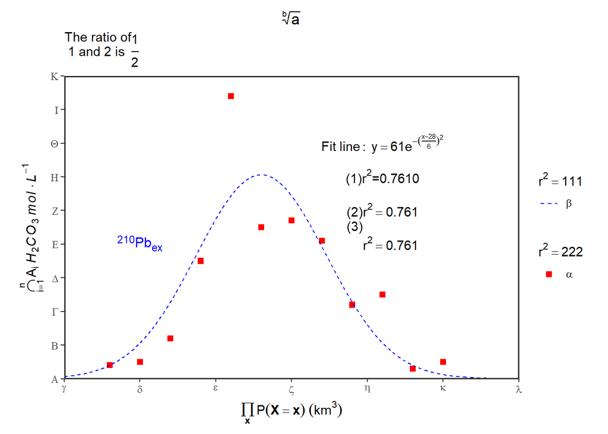

```r
# 加载包
library(data.table)
library(ggplot2)
library(ggtext)
library(latex2exp)

# 数据
point <- data.table(px = c(18,20,22,24,26,28,30,32,34,36,38,40),
                    py = c(4,5,12,35,84,45,47,41,22,25,3,5))
fline <- data.table(lx = seq(15, 43, by = 0.02),
                    ly = 60.5921*exp(-((seq(15, 43, by = 0.02)-28.0006)/6.0670)^2))

x.labl <- c(expression(gamma),expression(delta),expression(epsilon),
            expression(zeta),expression(eta),expression(kappa),expression(lambda))
y.labl <- c(expression(Alpha), expression(Beta), expression(Gamma), expression(Delta),
            expression(Epsilon), expression(Zeta), expression(Eta), expression(Theta),
            expression(Iota), expression(Kappa))

# 绘图
ggplot()+
  # 示例图层
  geom_point(data=point, aes(px, py, shape="sha"), colour="red", size=2)+   #给定一个shape的名称为sha
  geom_line(data=fline, aes(lx, ly, color="col"), linetype=2)+
  # 图内标记文字，只接受字符型+parse=T
  geom_text(data=NULL, aes(36, 70), label="Fit~line:~y == 61*e^{-(frac(x-28,6))}^2", parse=T)+  #基础用法，字符型转公式型
  annotate("text", x=36, y=60, label="'(1)'*r^2*'='*'0.7610'", parse=T)+                        #基础用法，字符型转公式型
  annotate("text", x=36, y=50, label="'(2)'*r^2==0.7610", parse=T)+                             #同上，但数值用公式型，多余0会被约掉
  annotate("text", x=36, y=40, label=TeX("(3)\n$r^2=0.7610$", output="character"), parse=T)+    #latex2exp::TeX，latex语法转字符型转公式型，纯文本可换行
  # 图内标记文字，额外包(不推荐)，用ggtext::geom_richtext，markdown语法，只支持有限html标签（不含math），且绘图效果类似geom_label，默认有边框和底纹
  geom_richtext(aes(x=20, y=40), label="<sup>210</sup>Pb<sub>ex</sub>", fill=NA, text.colour="blue", label.colour=NA, size=4)+
  # 图例title，直接用公式型，或其他包转为公式型
  guides(color=guide_legend(title=expression(r^2 == 111), order=1))+    #基础用法，公式型
  guides(shape=guide_legend(title=TeX("$r^2=222$"), order=2))+          #latex语法，默认输出公式型
  # 图例key，直接用公式型，或其他包转为公式型
  scale_color_manual(values=c("col"="blue"), labels=expression(beta))+  #基础用法，公式型
  scale_shape_manual(values=c("sha"=15), labels=TeX("$\\alpha$"))+      #latex语法，默认输出公式型
  # 坐标轴标签，直接用公式型
  scale_x_continuous(breaks=seq(15, 45, by=5), limits=c(15, 45), expand=c(0,0), labels=x.labl)+
  scale_y_continuous(breaks=seq(0, 90, by=10), limits=c(0, 90),  expand=c(0,0), labels=y.labl)+
  # 坐标轴、图标题，直接用公式型，或其他包转为公式型
  labs(
    # 公式换行测试
    # title=TeX("fasdfasd\nfadfadf")                           #纯文本，可以
    # title=expression("fasdfasd\nfadfadf")                    #纯文本，可以
    # title=expression(''^210*Pb[ex]*'\n'*CO[2])               #文本+公式，不换行
    # title=TeX("$^{210}Pb_ex$ \n $CO_2$")                     #文本+公式，报错，若为\\n，则不换行
    # title="CO<sub>2</sub><br><sup>210</sup>pb<sub>ex</sub>"  #需配合element_markdown()，实现存在基础符号的换行
    title=expression(sqrt(a,b)),                                         #基础用法，公式型
    subtitle = TeX("The ratio of\n 1 and 2 is $\\frac{1}{2}$"),          #latex语法，纯文本可换行
    x=expression(bold(prod(plain(P)(X==x), x))~(km^3)),                  #基础用法，公式型
    y=expression(intersect(A[i], i==1, n)~italic(H[2]*CO[3]~mol%.%L^-1)) #基础用法，公式型
  )+
  theme_bw()+
  theme(aspect.ratio=1/1.5,
        panel.border=element_rect(linewidth=1),
        panel.grid.major=element_blank(),
        panel.grid.minor=element_blank(),
        plot.title=element_text(hjust=0.5))
```

## 1.2 element_markdown案例

使用ggtext::element_markdown修改分面标题，此处不能用expression。另外这种用法只支持标题等位置，不支持全局如`theme(text=element_markdwon)`，因此在`annotate`和`geom_text`中不能用

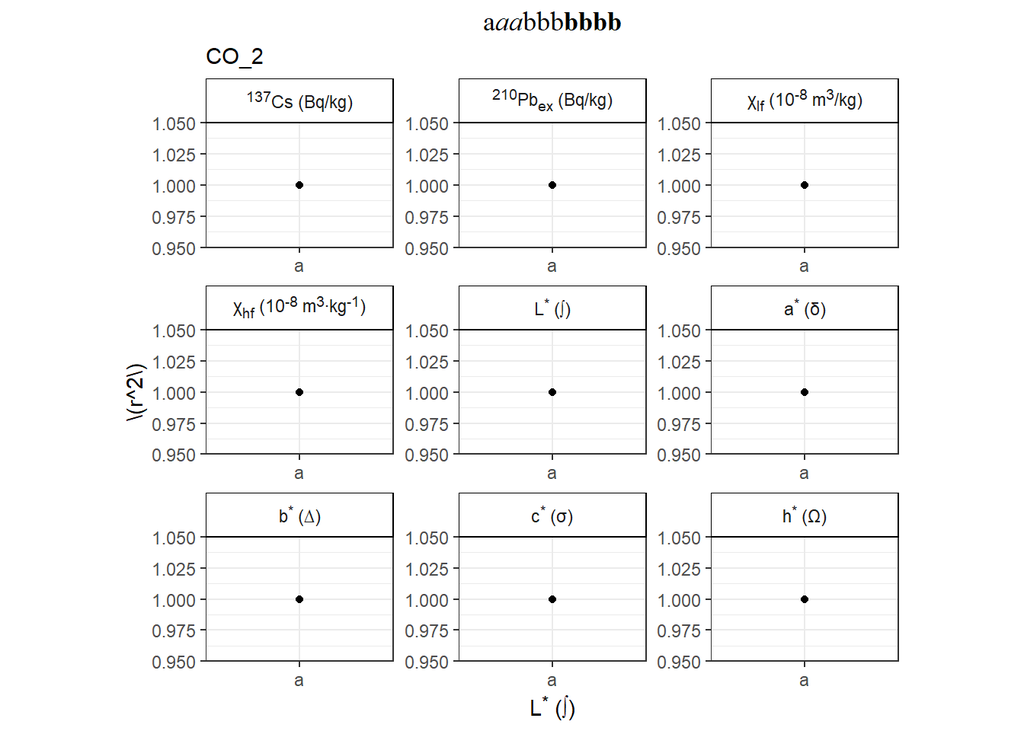

```r
# 加载包
library(ggplot2)
library(data.table)
library(magrittr)
library(ggtext)

# 注意，数据中需要定义因子及顺序，以确定分面的先后顺序
tracers <- c("cs137", "pb210", "xlf", "xhf", "L_star", "a_star", "b_star", "c_star", "h_star")
data <- data.table(class = "a", tracer = tracers, value = 1) %>% .[,tracer:=factor(tracer, levels=tracers)]
ename <- c("cs137"  = "<sup>137</sup>Cs (Bq/kg)",
           "pb210"  = "<sup>210</sup>Pb<sub>ex</sub> (Bq/kg)",
           "xlf"    = "&chi;<sub>lf</sub> (10<sup>-8</sup> m<sup>3</sup>/kg)",
           "xhf"    = "&chi;<sub>hf</sub> (10<sup>-8</sup> m<sup>3</sup>&#8729;kg<sup>-1</sup>)",
           "L_star" = "L<sup>*</sup> (&int;)",
           "a_star" = "a<sup>*</sup> (&delta;)",
           "b_star" = "b<sup>*</sup> (&#8710;)",
           "c_star" = "c<sup>*</sup> (&sigma;)",
           "h_star" = "h<sup>*</sup> (&Omega;)")
# 绘图
ggplot(data, aes(class, value)) +
  geom_point()+
  facet_wrap(tracer~., scales = "free", labeller = as_labeller(ename)) +
  labs(
    x="L<sup>*</sup> (&int;)",        #只支持简单符号
    y="$r^2$",                        #不支持公式
    title="a*aa*bbb**bbbb**",         #支持简单方法
    subtitle="CO_2"                   #不是markdown或html的下标语法
  )+
  theme_bw() +
  theme(aspect.ratio = 1/1.5,
        axis.title.x = element_markdown(hjust=0.5),                  #x轴标题
        axis.title.y = element_markdown(),                           #y轴标题
        plot.title = element_markdown(hjust=0.5, family="serif"),    #图标题
        plot.subtitle = element_markdown(),                          #图次标题
        strip.text = element_markdown(),                             #分面标题
        strip.background = element_rect(fill="white", color="black")
        )
```

## 1.3 分面标记

存在分面的情况下，建议使用`geom_text`在绘图区显示公式，可针对特定分面进行公式标记，方法是在标记数据中添加分面变量项，并在这列中指定每一行（即每个标签）对应的分面。这个变量不用在绘图代码中出现，ggplot会自动识别，但注意如果出现了绘图数据中不存在的分面值，则会单独创建一个分面。

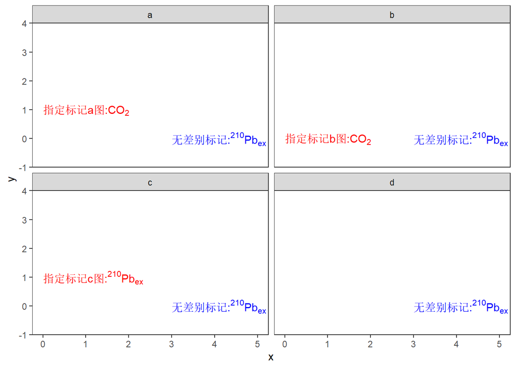

```r
# 加载包
library(ggplot2)
library(latex2exp)

# 空白数据
dftest <- data.frame(x=rep(0:5, time=5), y=rep(0:4, each=6), f=rep(c("a","b","c","d"), each=30))

# 绘图
ggplot(dftest, aes(x,y))+
  facet_wrap(~f)+
  # 1. geom_text，为特定分面添加标注，在df中包含分面列，ggplot可以自动识别
  # 1.1 直接在df中定义xyl，让ggplot自动识别分面变量
  geom_text(data=data.frame(x=0, y=0, f="b", l="'指定标记b图:'*CO[2]"), aes(label=l), parse=T, color="red", hjust=0)+
  # 1.2 为不同分面添加不同标注
  geom_text(data=data.frame(x=0, y=1, f=c("a", "c"), l=c("'指定标记a图:'*CO[2]", "'指定标记c图:'^{210}*Pb[ex]")), aes(label=l), parse=T, color="red", hjust=0)+
  # 2. annotate，无分面差别添加标注，字符型、expression、TeX
  annotate('text',x=3,y=0,label="'无差别标记:'^{210}*Pb[ex]",parse=T,color="blue",hjust=0)+
  # 布局和主题
  scale_x_continuous(limits = c(0,5), expand=c(0.05,0))+
  scale_y_continuous(limits = c(-1,4), expand=c(0,0))+
  theme_bw()+
  theme(
    panel.grid = element_blank(),
  )
```

## 1.4 综合案例

一个综合案例，修改自知乎回答：[有大佬知道这种图怎么用R画吗？](https://www.zhihu.com/question/639214009/answer/3594401726)

案例中的用法总结：

- purrr包：
- map函数，对向量或列表的每个元素执行函数
- map(c(3.5, 4.8, 5.3, 6, 12, 14.3, 15, 17), ~rnorm(6, .x, 1)) #结果只能是列表
- map_dbl(c(3.5, 4.8, 5.3, 6, 12, 14.3, 15, 17), ~rnorm(6, .x, 1)) 错，因为结果是list，不能直接输出向量
- 如果将上面的列表转换为向量，可以使用purrr::flatten_dbl，效果和unlist一样
- stat_summary，由于原始数据中，并不是最终结果，需要进行总结，即求平均值和最值，这与先求总结数据再画图是一样的
- fun.data=mean_cl_normal，求原始数据的均值和95%置信区间，用于errorbar画限，类似的函数还有：
- mean_cl_normal(x, …)：均值和正态分布假设的t分布的95置信区间。
- mean_cl_boot(x, …)：均值和非参数bootstrap方法的置信区间。
- mean_sdl(x, …)：均值和标准差
- median_hilow(x, …)：中位数和外部量化数（通常是25%和75%分位数）
- fun，计算出一个变量，与上面的fun.data不同，它返回的数据有多个变量
- 注意不管是fun.data还是fun，定义函数后，返回的都是aes变量，即有两者后，不必再去aes中定义相关映射

注意:

- 更新至ggplot2的v4.0.0后，分面y标题部分，不能正常渲染为markdown了，这似乎是个bug，等待修复吧
- expression中，没有换行语句，如果只有两行，可以用atop(a,b)实现，但这实际上是一个数学符号，类似没有分数没有中间的线，而且结果中ab字号大小不同
- 本例使用多个公式，替代公式内部换行，需重新组织标记数据，这种做法缺陷是，行距需要在数据中逐个自定义，并根据绘图效果反过来调节，比较麻烦
- 在geom_text或者annotate(geom=“text”)中，如果使用expression或者latex，会报警告，这个问题很难解决https://github.com/tidyverse/ggplot2/issues/4644，目前也不用管
- 使用geom_text为不同分面标记公式，则必须在标记数据中有facet列，用于定义geom_text出现在哪个分面，但是并不需要传递给aes，而是ggplot2自动识别分面变量，甚至如果标记数据中的face列，出现了与绘图数据中不同的分面名，则会单独创建一个分面，用于文字标记

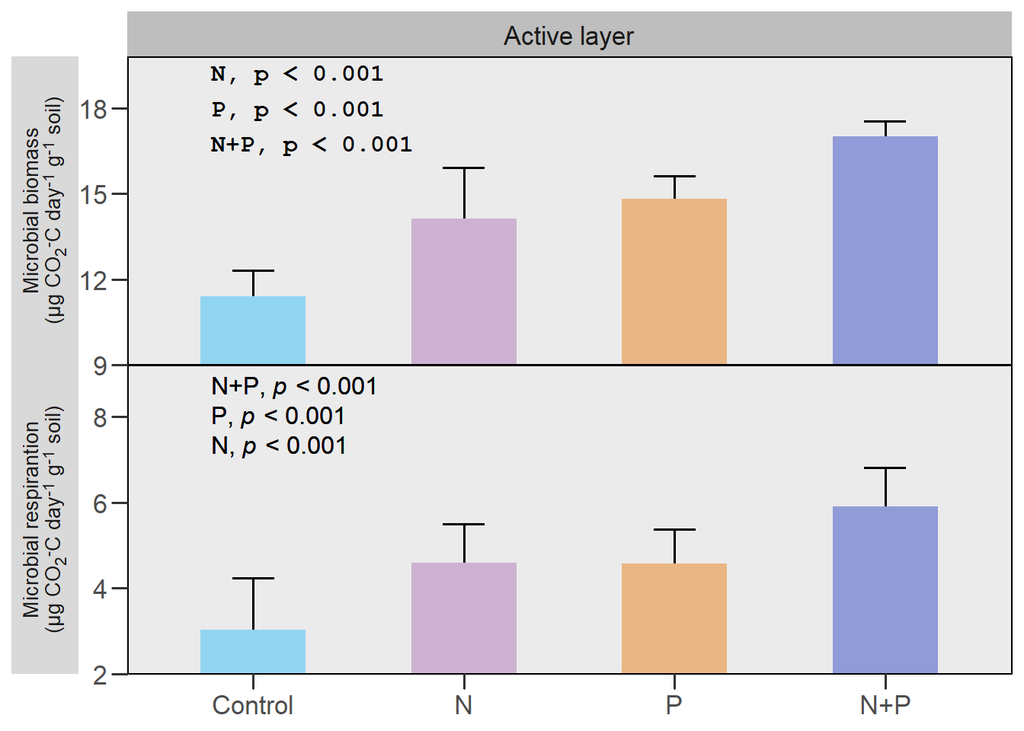

```r
# 所需包
library(purrr)
library(stringr)
library(ggplot2)
library(ggh4x)
library(ggview)
library(ggtext)
library(ggthemes)

# 数据，注意此数据中，Res对应均值较低，Bio对应均值较高
p_class <- c("Control", "N", "P", "N+P")
p_facet <- c("Res", "Bio")
tableRaw <- data.frame(
  x = rep(p_class, each=6, length.out=48) %>% factor(levels=p_class),
  y = map(c(3.5, 4.8, 5.3, 6, 12, 14.3, 15, 17), ~rnorm(6, .x, 1)) %>% flatten_dbl(),
  facet = rep(p_facet, each=24) %>% factor(levels=rev(p_facet)),             #替换一下顺序，让Bio子图在上面
  fill = rep(c("#92D5F2", "#CDB2D3", "#EAB684", "#919BD8"), each=6, length.out=48)
)

# 用字符型公式进行标记，在Res子图
tableLab1 <- data.frame(
  x=0.8, y=c(7.3, 8, 8.7),
  l=c("'N, '*italic(p)*' < 0.001'", "'P, '*italic(p)*' < 0.001'", "'N+P, '*italic(p)*' < 0.001'") %>% rep(time=2),
  facet=c("Res") %>% rep(each=3)
)
# 用字符型进行标记，在Bio子图
tableLab2 <- data.frame(
  x=0.8, y=18,
  l=str_c(
    str_pad(
      c("N, p < 0.001", "P, p < 0.001", "N+P, p < 0.001"),
      width = 14,                                #最终每个字符串的总长度应该为12个字符。
      pad = " ",                                 #如不满足用空格填充
      side = "right",                            #填充位置为右侧
      use_width = F                              #不考虑特殊字符（如中文）
    ), collapse = "\n"),                         #字符串之间用换行符连接
  facet=c("Bio")
)

# 画图相同部分
ggplot(tableRaw, aes(x, y, fill=fill)) +
  stat_summary(geom="errorbar", fun.data=mean_cl_normal, width=.2) +
  stat_summary(geom="col", fun.data=mean_cl_normal, width=.5) +

  # 标记，Res子图是以字符型转公式型标记，Bio子图用字符型进行标记
  geom_text(data = tableLab1, aes(x, y, label=l), inherit.aes = F, parse = T, hjust=0, family = "sans")+
  geom_text(data = tableLab2, aes(x, y, label=l), inherit.aes = F, hjust=0, family = "mono", fontface="bold")+

  scale_fill_identity() +
  facet_grid2(
    facet~"Active layer",         #类似aes，用字符型，新建了一个变量用于列分面，并在label中定义了显示内容
    switch = "y",                 #y轴标签放到左侧
    scales = "free_y",
    labeller = as_labeller(       #替换标签显示内容，使用html语法，并通过theme中的ggtext::element_markdown转换
      c(
        "Res" = "Microbial respirantion<br>(μg CO<sub>2</sub><sup>-</sup>C day<sup>-1</sup> g<sup>-1</sup> soil)",
        "Bio" = "Microbial biomass<br>(μg CO<sub>2</sub><sup>-</sup>C day<sup>-1</sup> g<sup>-1</sup> soil)",
        "Active layer" = "Active layer"
      )
    )
  ) +
  facetted_pos_scales(            #自定义每个分面的轴标度
    y = list(
      facet=="Res" ~ scale_y_continuous(expand = expansion(mult = c(0,.2)),limits = c(2,8)),
      facet=="Bio" ~ scale_y_continuous(expand = expansion(mult = c(0,.2)),limits = c(9,18), breaks = c(9,12,15,18))
    )
  ) +
  labs(x=NULL, y=NULL) +
  theme_base() +
  theme(
    panel.spacing = unit(0,"cm"),                    #上下两个分面之间的距离
    strip.placement = "outside",                     #分面标签的位置，这里是y轴标签的外侧
    strip.background.x = element_rect(fill="grey"),  #分面标签的背景色
    strip.switch.pad.grid = unit(0,"cm"),            #分面标签与绘图区域的距离，这里是紧贴
    strip.text.y.left = element_markdown(size=10)    #ggplot2 v4.0.0，需要指定明确，用strip.text.y不行
  )
```

## 1.5 expression语法总结

总结了`?plotmath`中提到的expression各种符号

### 1.5.1 基础运算符

加减乘除等基础运算符

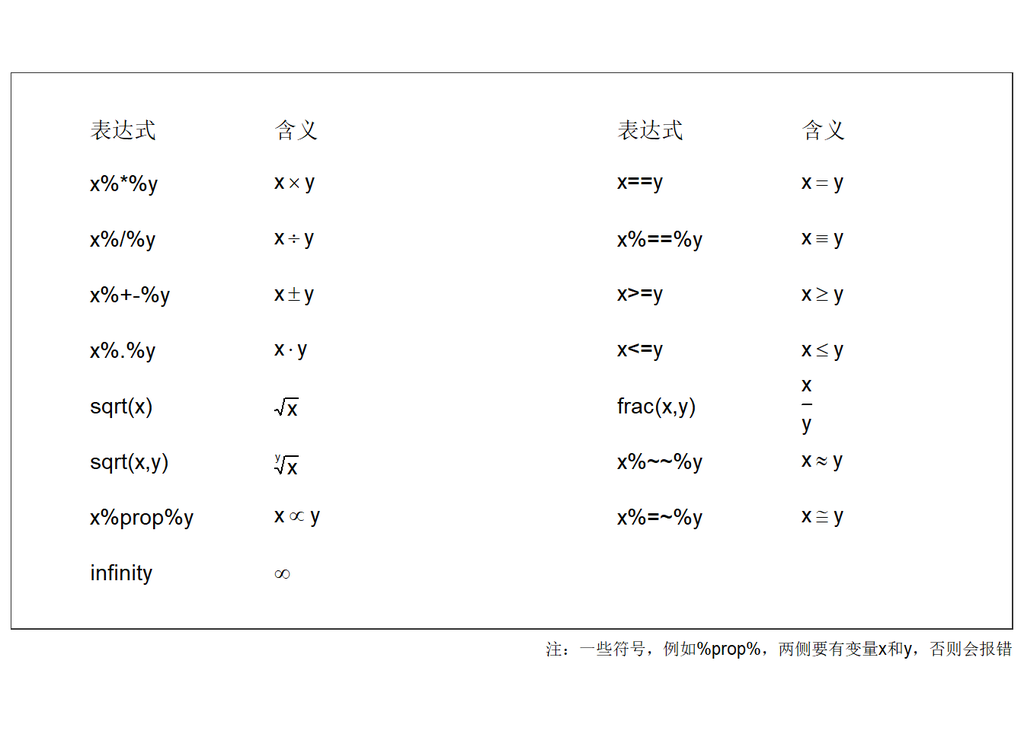

```r
# 加载包
library(data.table)
library(ggplot2)
library(magrittr)

# 符号
dt.01 <- data.table(
  x=c(rep(c(1,1.7),9), rep(c(3,3.7), 8)),
  y=c(rep(9:1, each=2), rep(9:2, each=2)),
  l=c("'表达式'",    "'含义'",
      "'x%*%y'",     "x%*%y",
      "'x%/%y'",     "x%/%y",
      "'x%+-%y'",    "x%+-%y",
      "'x%.%y'",     "x%.%y",
      "'sqrt(x)'",   "sqrt(x)",
      "'sqrt(x,y)'", "sqrt(x,y)",
      "'x%prop%y'",  "x%prop%y",
      "'infinity'",  "infinity",
      "'表达式'",    "'含义'",
      "'x==y'",      "x==y",
      "'x%==%y'",    "x%==%y",
      "'x>=y'",      "x>=y",
      "'x<=y'",      "x<=y",
      "'frac(x,y)'", "frac(x,y)",
      "'x%~~%y'",    "x%~~%y",
      "'x%=~%y'",    "x%=~%y")
)

# 绘图
ggplot()+
  geom_text(data = dt.01, aes(x,y,label=l), hjust=0, parse = T)+
  scale_x_continuous(limits = c(0.7,4.5), expand = c(0,0))+
  scale_y_continuous(limits = c(0,10), expand = c(0,0))+
  labs(x=NULL, y=NULL, title=NULL, caption = "注：一些符号，例如%prop%，两侧要有变量x和y，否则会报错")+
  theme_bw()+
    theme(aspect.ratio = 1/1.8,
          axis.text = element_blank(),
          axis.ticks = element_blank(),
          panel.grid = element_blank())
```

### 1.5.2 特殊字体

粗体、斜体、下划线等

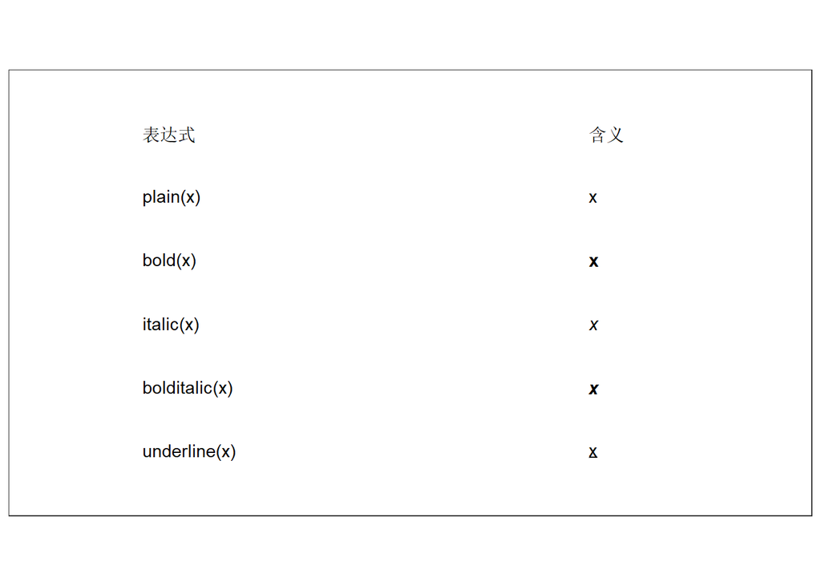

```r
# 加载包
library(data.table)
library(ggplot2)
library(magrittr)

# 符号
dt.02 <- data.table(
  x=c(rep(c(1,2),6)),
  y=c(rep(6:1, each=2)),
  l=c("'表达式'",        "'含义'",
      "'plain(x)'",      "plain(x)",
      "'bold(x)'",       "bold(x)",
      "'italic(x)'",     "italic(x)",
      "'bolditalic(x)'", "bolditalic(x)",
      "'underline(x)'",  "underline(x)")
)

# 绘图
ggplot()+
  geom_text(data = dt.02, aes(x,y,label=l), hjust=0, parse = T)+
  scale_x_continuous(limits = c(0.7, 2.5), expand = c(0,0))+
  scale_y_continuous(limits = c(0, 7), expand = c(0,0))+
  labs(x=NULL, y=NULL, title=NULL)+
    theme_bw()+
    theme(aspect.ratio = 1/1.8,
          axis.text = element_blank(),
          axis.ticks = element_blank(),
          panel.grid = element_blank())
```

### 1.5.3 希腊字母（小写）

小写希腊字母

注意，可以使用`symbol(x)`从英文字母映射到希腊字母（大写或小写），但是这个映射关系没找到官方文档，所以这里没展示，也不建议用

[figure not shown]

```r
# 加载包
library(data.table)
library(ggplot2)
library(magrittr)

# 符号
dt.03 <- data.table(
  x=c(rep(c(1,2),18), rep(c(3,4), 18)),
  y=c(rep(18:1, each=2), rep(18:1,each=2)),
  l=c("'表达式'",        "'含义'",
      "'alpha'",         "alpha",
      "'beta'",          "beta",
      "'gamma'",         "gamma",
      "'delta'",         "delta",
      "'epsilon'",       "epsilon",
      "'zeta'",          "zeta",
      "'eta'",           "eta",
      "'theta'",         "theta",
      "'iota'",          "iota",
      "'kappa'",         "kappa",
      "'lambda'",        "lambda",
      "'mu'",            "mu",
      "'nu'",            "nu",
      "'xi'",            "xi",
      "'omicron'",       "omicron",
      "'pi'",            "pi",
      "'rho'",           "rho",
      "'表达式'",        "含义",
      "'sigma'",         "sigma",
      "'tau'",           "tau",
      "'upsilon'",       "upsilon",
      "'phi'",           "phi",
      "'chi'",           "chi",
      "'psi'",           "psi",
      "'omega'",         "omega",
      "'25:varphi'",     "varphi",
      "'26:varepsilon'", "varepsilon",
      "'27:digamma'",    "digamma",
      "'28:stigma'",     "stigma",
      "'29:koppa'",      "koppa",
      "'30:sampi'",      "sampi",
      "'31:phi1'",       "phi1",
      "'32:omega1'",     "omega1",
      "'33:theta1'",     "theta1",
      "'34:sigma1'",     "sigma1")
)

# 绘图
ggplot()+
  geom_text(data = dt.03, aes(x,y,label=l), hjust=0, parse = T)+
  scale_x_continuous(limits = c(0.7, 4.5), expand = c(0,0))+
  scale_y_continuous(limits = c(0, 19), expand = c(0,0))+
  labs(x=NULL, y=NULL, title=NULL, caption = "注：25~34为特殊符号，有的不能在ggplot2中显示")+
    theme_bw()+
    theme(aspect.ratio = 1/1.8,
          axis.text = element_blank(),
          axis.ticks = element_blank(),
          panel.grid = element_blank())
```

### 1.5.4 希腊字母（大写）

大写希腊字母

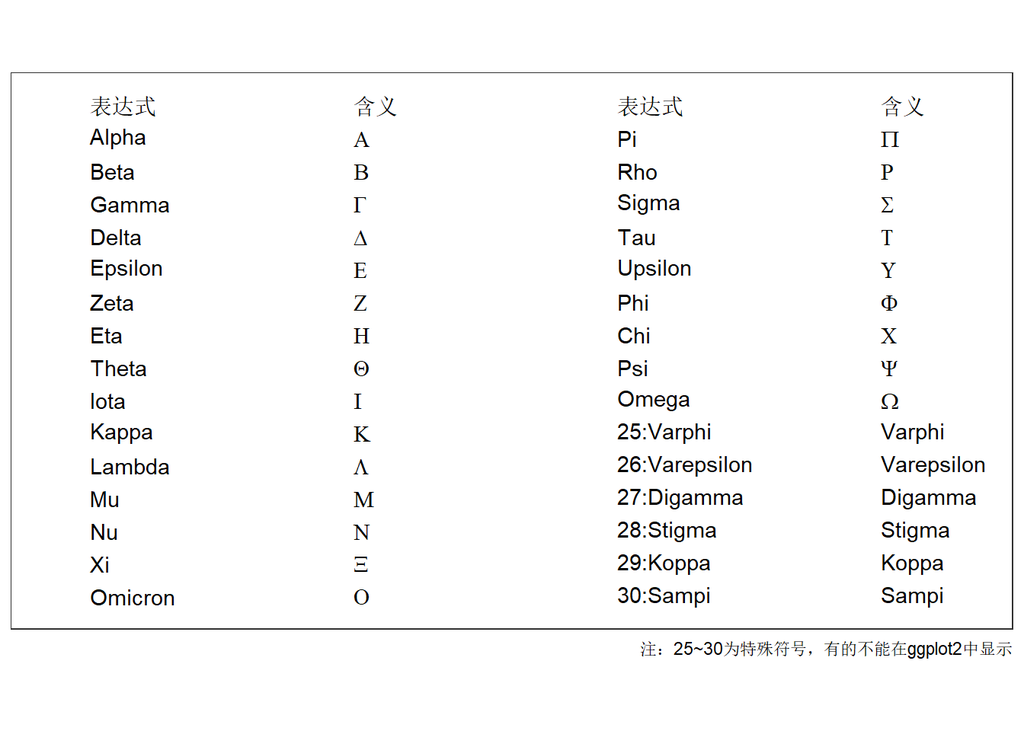

```r
# 加载包
library(data.table)
library(ggplot2)
library(magrittr)

# 符号
dt.04 <- data.table(
  x=c(rep(c(1,2),16), rep(c(3,4), 16)),
  y=c(rep(16:1, each=2), rep(16:1,each=2)),
  l=c("'表达式'",        "'含义'",
      "'Alpha'",         "Alpha",
      "'Beta'",          "Beta",
      "'Gamma'",         "Gamma",
      "'Delta'",         "Delta",
      "'Epsilon'",       "Epsilon",
      "'Zeta'",          "Zeta",
      "'Eta'",           "Eta",
      "'Theta'",         "Theta",
      "'Iota'",          "Iota",
      "'Kappa'",         "Kappa",
      "'Lambda'",        "Lambda",
      "'Mu'",            "Mu",
      "'Nu'",            "Nu",
      "'Xi'",            "Xi",
      "'Omicron'",       "Omicron",
      "'表达式'",        "含义",
      "'Pi'",            "Pi",
      "'Rho'",           "Rho",
      "'Sigma'",         "Sigma",
      "'Tau'",           "Tau",
      "'Upsilon'",       "Upsilon",
      "'Phi'",           "Phi",
      "'Chi'",           "Chi",
      "'Psi'",           "Psi",
      "'Omega'",         "Omega",
      "'25:Varphi'",     "Varphi",
      "'26:Varepsilon'", "Varepsilon",
      "'27:Digamma'",    "Digamma",
      "'28:Stigma'",     "Stigma",
      "'29:Koppa'",      "Koppa",
      "'30:Sampi'",      "Sampi")
)

# 绘图
ggplot()+
  geom_text(data = dt.04, aes(x,y,label=l), hjust=0, parse = T)+
  scale_x_continuous(limits = c(0.7, 4.5), expand = c(0,0))+
  scale_y_continuous(limits = c(0, 17), expand = c(0,0))+
  labs(x=NULL, y=NULL, title=NULL, caption = "注：25~30为特殊符号，有的不能在ggplot2中显示")+
    theme_bw()+
    theme(aspect.ratio = 1/1.8,
          axis.text = element_blank(),
          axis.ticks = element_blank(),
          panel.grid = element_blank())
```

### 1.5.5 上下标

上下标

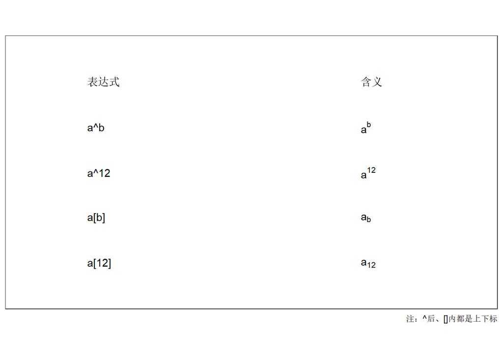

```r
# 加载包
library(data.table)
library(ggplot2)
library(magrittr)

# 符号
dt.05 <- data.table(
  x=c(rep(c(1,2),5)),
  y=c(rep(5:1, each=2)),
  l=c("'表达式'", "'含义'",
      "'a^b'",    "a^b",
      "'a^12'",   "a^12",
      "'a[b]'",   "a[b]",
      "'a[12]'",  "a[12]")
)

# 绘图
ggplot()+
  geom_text(data = dt.05, aes(x,y,label=l), hjust=0, parse = T)+
  scale_x_continuous(limits = c(0.7, 2.5), expand = c(0,0))+
  scale_y_continuous(limits = c(0, 6), expand = c(0,0))+
  labs(x=NULL, y=NULL, title=NULL, caption = "注：^后、[]内都是上下标")+
  theme_bw()+
  theme(aspect.ratio = 1/1.8,
        axis.text = element_blank(),
        axis.ticks = element_blank(),
        panel.grid = element_blank())
```

### 1.5.6 大型运算符

求和、求积、积分、交并集、极限、组合（Cn的另一种写法）

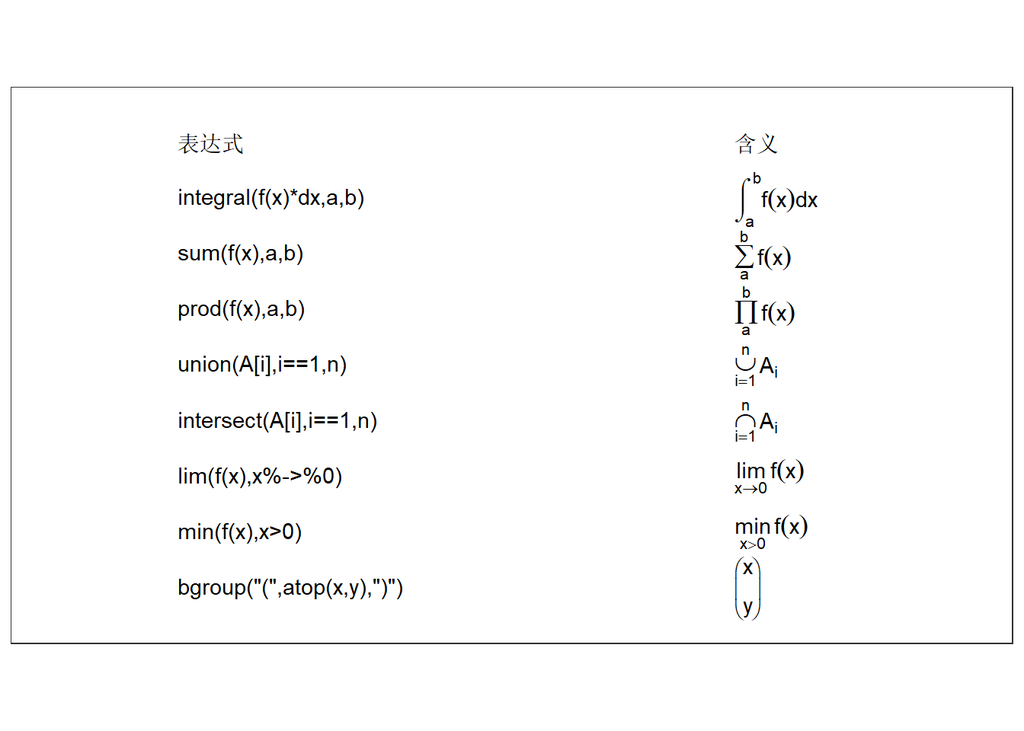

```r
# 加载包
library(data.table)
library(ggplot2)
library(magrittr)

# 符号
dt.06 <- data.table(
  x=c(rep(c(1,2),9)),
  y=c(rep(9:1, each=2)),
  l=c("'表达式'", "'含义'",
      "'integral(f(x)*dx,a,b)'",         "integral(f(x)*dx,a,b)",
      "'sum(f(x),a,b)'",                 "sum(f(x),a,b)",
      "'prod(f(x),a,b)'",                "prod(f(x),a,b)",
      "'union(A[i],i==1,n)'",            "union(A[i],i==1,n)",
      "'intersect(A[i],i==1,n)'",        "intersect(A[i],i==1,n)",
      "'lim(f(x),x%->%0)'",              "lim(f(x),x%->%0)",
      "'min(f(x),x>0)'",                 "min(f(x),x>0)",
      "'bgroup(\"(\",atop(x,y),\")\")'", "bgroup(\"(\",atop(x,y),\")\")")
)

# 绘图
ggplot()+
  geom_text(data = dt.06, aes(x,y,label=l), hjust=0, parse = T)+
  scale_x_continuous(limits = c(0.7, 2.5), expand = c(0,0))+
  scale_y_continuous(limits = c(0, 10), expand = c(0,0))+
  labs(x=NULL, y=NULL, title=NULL)+
  theme_bw()+
  theme(aspect.ratio = 1/1.8,
        axis.text = element_blank(),
        axis.ticks = element_blank(),
        panel.grid = element_blank())
```

### 1.5.7 箭头

箭头符号

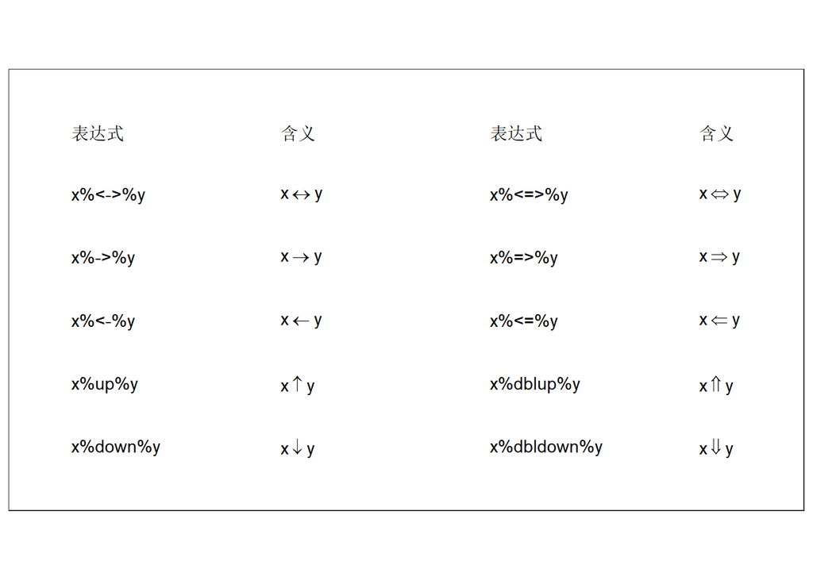

```r
# 加载包
library(data.table)
library(ggplot2)
library(magrittr)

# 符号
dt.07 <- data.table(
  x=c(rep(c(1,2),6), rep(c(3,4), 6)),
  y=c(rep(6:1, each=2), rep(6:1,each=2)),
  l=c("'表达式'", "'含义'",
      "'x%<->%y'",     "x%<->%y",
      "'x%->%y'",      "x%->%y",
      "'x%<-%y'",      "x%<-%y",
      "'x%up%y'",      "x%up%y",
      "'x%down%y'",    "x%down%y",
      "'表达式'",      "'含义'",
      "'x%<=>%y'",     "x%<=>%y",
      "'x%=>%y'",      "x%=>%y",
      "'x%<=%y'",      "x%<=%y",
      "'x%dblup%y'",   "x%dblup%y",
      "'x%dbldown%y'", "x%dbldown%y")
)

# 绘图
ggplot()+
  geom_text(data = dt.07, aes(x,y,label=l), hjust=0, parse = T)+
  scale_x_continuous(limits = c(0.7, 4.5), expand = c(0,0))+
  scale_y_continuous(limits = c(0, 7), expand = c(0,0))+
  labs(x=NULL, y=NULL, title=NULL)+
  theme_bw()+
  theme(aspect.ratio = 1/1.8,
        axis.text = element_blank(),
        axis.ticks = element_blank(),
        panel.grid = element_blank())
```

### 1.5.8 集合运算符

子集、属于、不属于

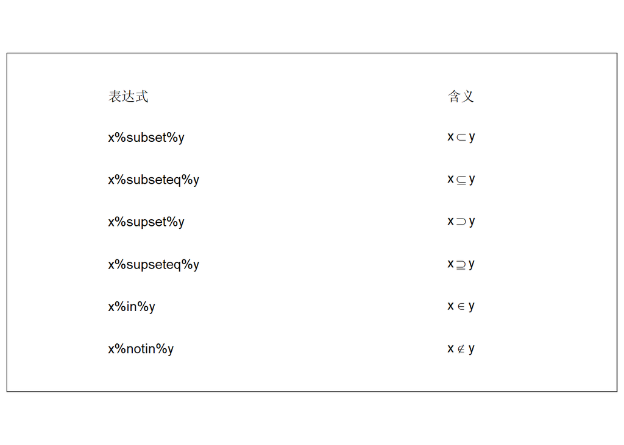

```r
# 加载包
library(data.table)
library(ggplot2)
library(magrittr)

# 符号
dt.08 <- data.table(
  x=c(rep(c(1,2),7)),
  y=c(rep(7:1, each=2)),
  l=c("'表达式'", "'含义'",
      "'x%subset%y'",   "x%subset%y",
      "'x%subseteq%y'", "x%subseteq%y",
      "'x%supset%y'",   "x%supset%y",
      "'x%supseteq%y'", "x%supseteq%y",
      "'x%in%y'",       "x%in%y",
      "'x%notin%y'",    "x%notin%y")
)

# 绘图
ggplot()+
  geom_text(data = dt.08, aes(x,y,label=l), hjust=0, parse = T)+
  scale_x_continuous(limits = c(0.7, 2.5), expand = c(0,0))+
  scale_y_continuous(limits = c(0, 8), expand = c(0,0))+
  labs(x=NULL, y=NULL, title=NULL)+
  theme_bw()+
  theme(aspect.ratio = 1/1.8,
        axis.text = element_blank(),
        axis.ticks = element_blank(),
        panel.grid = element_blank())
```

### 1.5.9 导数微分符号

导数、微分符号

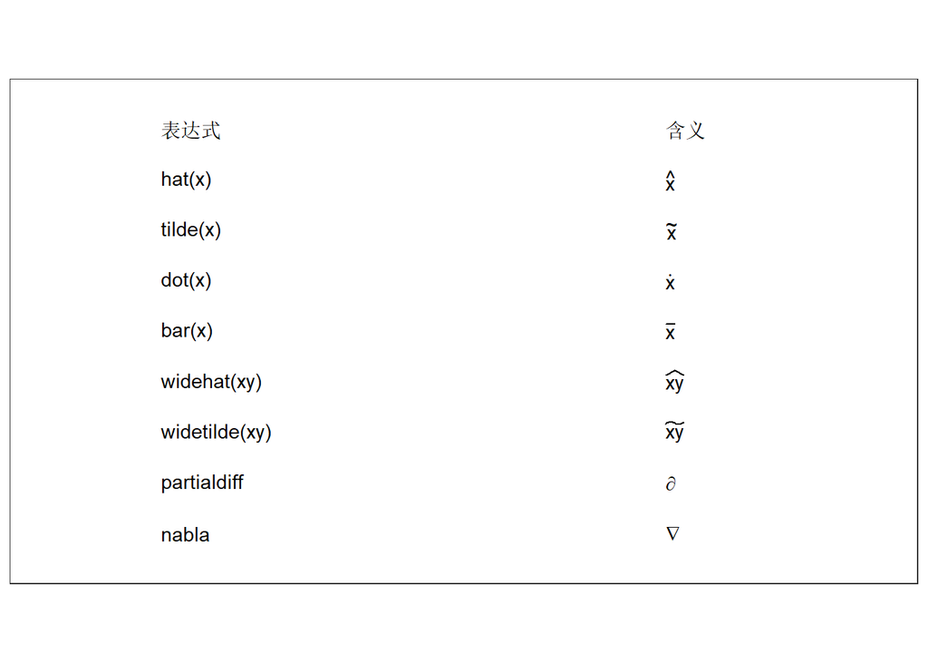

```r
# 加载包
library(data.table)
library(ggplot2)
library(magrittr)

# 符号
dt.09 <- data.table(
  x=c(rep(c(1,2),9)),
  y=c(rep(9:1, each=2)),
  l=c("'表达式'",        "'含义'",
      "'hat(x)'",        "hat(x)",
      "'tilde(x)'",      "tilde(x)",
      "'dot(x)'",        "dot(x)",
      "'bar(x)'",        "bar(x)",
      "'widehat(xy)'",   "widehat(xy)",
      "'widetilde(xy)'", "widetilde(xy)",
      "'partialdiff'",   "partialdiff",
      "'nabla'",         "nabla")
)

# 绘图
ggplot()+
  geom_text(data = dt.09, aes(x,y,label=l), hjust=0, parse = T)+
  scale_x_continuous(limits = c(0.7, 2.5), expand = c(0,0))+
  scale_y_continuous(limits = c(0, 10), expand = c(0,0))+
  labs(x=NULL, y=NULL, title=NULL)+
  theme_bw()+
  theme(aspect.ratio = 1/1.8,
        axis.text = element_blank(),
        axis.ticks = element_blank(),
        panel.grid = element_blank())
```

### 1.5.10 其他

包括省略号、列表等

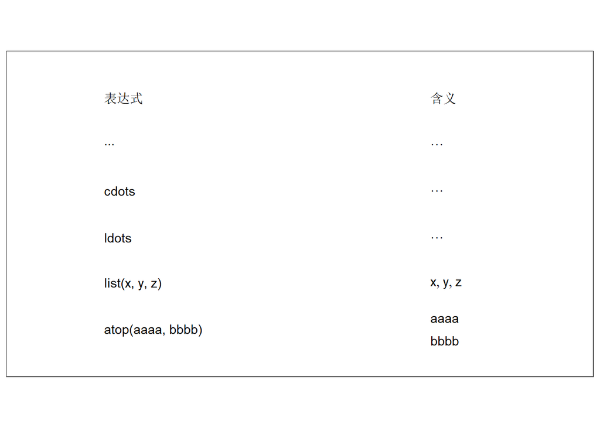

```r
# 加载包
library(data.table)
library(ggplot2)
library(magrittr)

# 符号
dt.10 <- data.table(
  x=c(rep(c(1,2),6)),
  y=c(rep(6:1, each=2)),
  l=c("'表达式'",           "'含义'",
      "'...'",              "...",
      "'cdots'",            "cdots",
      "'ldots'",            "ldots",
      "'list(x, y, z)'",    "list(x, y, z)",
      "'atop(aaaa, bbbb)'", "atop(aaaa, bbbb)"      )
)

# 绘图
ggplot()+
  geom_text(data = dt.10, aes(x,y,label=l), hjust=0, parse = T)+
  scale_x_continuous(limits = c(0.7, 2.5), expand = c(0,0))+
  scale_y_continuous(limits = c(0, 7), expand = c(0,0))+
  labs(x=NULL, y=NULL, title=NULL)+
  theme_bw()+
  theme(aspect.ratio = 1/1.8,
        axis.text = element_blank(),
        axis.ticks = element_blank(),
        panel.grid = element_blank())
```

# 2. 调整字体

注意：

**注意使用`sysfonts::font_families()`查看当前可用字体。以下几个字体一般可以直接在ggplot中使用，而不需要额外包（windows系统中）：’sans’是无衬线（Arial），’serif’是有衬线（times new roman），’mono’是等宽字体（Courier New）。**

**有时不能显示中文，可能是某些包不兼容，可以重启或关闭不需要的包试试**

1. 一个可行的ggplot2配置、显示字体流程：

1.1. 在R中查看哪些字体可用：`sysfonts::font_families()`；

1.2. 选择字体或使用`sysfonts::font_add()`用本地文件添加字体；

1.3. 使用`showtext::showtext_auto()`在ggplot2中显示字体；

1.4. 使用ggplot2画图并定义字体

2. windows字体保存位置`C:\Windows\Fonts`
3. 某些时候Rstudio的plot窗口不能显示字体，可在Tools - Global options - General - Graphics - Graphics Device - Backend修改参数，或者将图片保存本地后查看
4. 在Rstudio中绘图显示不同字体，与Rmd和Rmd保存为html时，显示结果不一样。例如有时windows系统字体虽然sysfonts::font_families()不显示，但是在Rstudio也能调用，如Times New Roman，但是在Rmd html中则必须要载入、调用，否则提示没有该字体。如果在Rstudio中可以直接用，则不建议showtext::showtext_auto()，因为它会让文字变得非常小，要显著调大size才能正常显示，也因此建议画完图后就用showtext::showtext_auto(FALSE)关闭该功能。

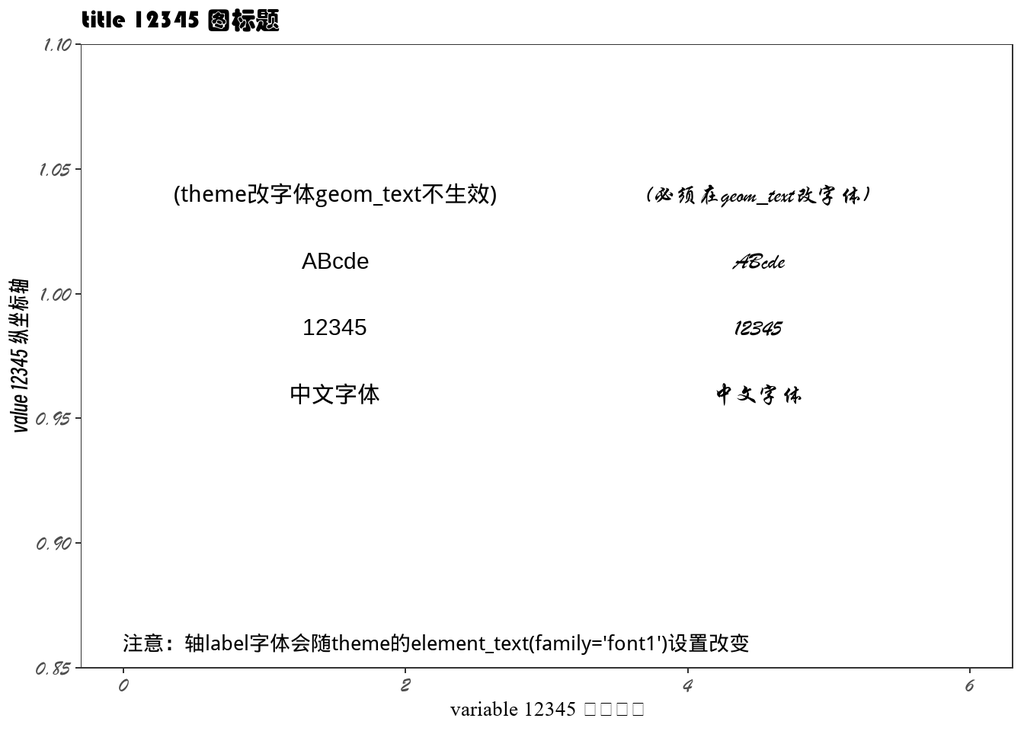

```r
# 加载包
library(ggplot2)
library(showtextdb)
library(sysfonts)
library(showtext)

# 加载字体
sysfonts::font_add("font1", regular = "D:/#R/learn_visualization/font/STXINGKA.TTF")
sysfonts::font_add("font2", regular = "D:/#R/learn_visualization/font/times.ttf")
sysfonts::font_add("font3", regular = "D:/#R/learn_visualization/font/SmileySans-Oblique.TTF")
sysfonts::font_add("font4", regular = "D:/#R/learn_visualization/font/STHUPO.TTF")
# sysfonts::font_families() #查看可行字体
showtext::showtext_auto()   #在ggplot2图中显示字体

# 绘图
p <- ggplot()+
  geom_text(aes(1.5,1),label="(theme改字体geom_text不生效)\nABcde\n12345\n中文字体",size=8)+
  geom_text(aes(4.5,1),label="(必须在geom_text改字体)\nABcde\n12345\n中文字体",size=8,family="font1")+
  geom_text(aes(0,0.86),label="注意：轴label字体会随theme的element_text(family='font1')设置改变",size=7,hjust=0)+
  scale_x_continuous(limits=c(0,6))+
  scale_y_continuous(limits=c(0.85,1.1), expand=c(0,0))+
  labs(x="variable 12345 横坐标轴", y="value 12345 纵坐标轴", title="title 12345 图标题")+
  theme_bw()+
  theme(panel.grid = element_blank(),
        text = element_text(family = "font1"),
        axis.text = element_text(size=20),
        axis.title.x = element_text(family = "font2", size=20),  #Times New Roman不显示中文
        axis.title.y = element_text(family = "font3", size=20),
        title = element_text(family = "font4", size=20))
# ggsave("text.tiff",p,width = 10, height = 10, units = "cm", dpi = 300) #保存图注意p的位置
print(p)
```

```r
showtext_auto(FALSE)
#画完图关闭，因为打开时画图文字会变得非常小，只能把字号设置的额外大才正常
```

# 3. 指示线

来自网上的一个画图案例，具体来源记不清了，此处精简了代码，画图效果不变。

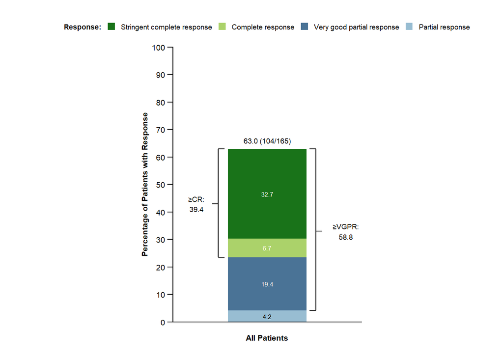

```r
# 加载包
library(ggplot2)
library(data.table)

# 生成数据
mydata <- data.table(response = c("Stringent complete response", "Complete response",
                                  "Very good partial response", "Partial response"),
                     percentage = c(0.327, 0.067, 0.194, 0.042))
mydata$response <- factor(mydata$response ,
                          levels = c("Stringent complete response", "Complete response", "Very good partial response", "Partial response"))
dat.col <- c("darkgreen", "darkolivegreen3", "steelblue4", "lightskyblue3")

# 生成标记
dat.tex <- data.table(x=c(1,0.55,1.5), y=c(0.66,0.43,0.33), l=c("63.0 (104/165)", " ≥CR: \n39.4", " ≥VGPR: \n58.8"))
dat.seg.left <- data.table(x=c(0.65,0.69,0.69,0.69),
                           xe=c(0.69,0.73,0.73,0.69),
                           y=c(0.43,0.63,0.236,0.236),
                           ye=c(0.43,0.63,0.236,0.63))
dat.seg.righ <- data.table(x=c(1.31,1.27,1.27,1.31),
                           xe=c(1.35,1.31,1.31,1.31),
                           y=c(0.33,0.63,0.042,0.042),
                           ye=c(0.33,0.63,0.042,0.63))

# 画图
ggplot(mydata, aes(x = "", y = percentage, fill = response)) +
  geom_bar(stat = "identity", width = 0.5, alpha = 0.9) +
  geom_text(aes(label = percentage * 100), position = position_stack(vjust = 0.5), size = 2.3, colour = c("white", "white", "white", "black")) +
  geom_text(data=dat.tex, aes(x,y,label=l,fill=NULL), size=2.5)+           #无法继承的aes为NULL
  geom_segment(data=dat.seg.left, aes(x=x,xend=xe,y=y,yend=ye,fill=NULL))+ #左侧{
  geom_segment(data=dat.seg.righ, aes(x=x,xend=xe,y=y,yend=ye,fill=NULL))+ #右侧{
  scale_fill_manual(values = dat.col) +
  scale_y_continuous(breaks = seq(0, 1, 0.1), label = seq(0, 100, 10), limits = c(0, 1), expand = c(0, 0)) +
  labs(x="All Patients", y="Percentage of Patients with Response", fill = "Response:") +
  coord_cartesian(clip = "off") +
  theme_classic() +
  theme(legend.position = "top",
        legend.text = element_text(size = 7),
        legend.title = element_text(size = 7, face = "bold"),
        legend.key.size = unit(3, "mm"),
        axis.title = element_text(size = 8, face = "bold"),
        axis.text = element_text(size = 8),
        axis.ticks.x = element_blank(),
        axis.ticks.length.y = unit(2, "mm"),
        plot.margin = unit(c(0.6, 5, 0.6, 5), "cm")
  )
```

# 4. 显著性标记

总结了显著性标记的几种方法

注意

1. bar，errorbar和text的position参数要相同
2. ggplot2中，调整errorbar图层至bar图层前面，可实现显示上半个errorbar，在ggpubr包中，可使用`error.plot = "upper_errorbar"`显示半个
3. 对于条形图，`ggplot()+geom_bar(stat="identity")`与`ggplot()+geom_col()`效果相同
4. 不想让aes继承，可以用这个参数inherit.aes = FALSE
5. ggplot2中只有mean_sdl，其中为2*sd，而ggpubr中有mean_sd
6. 标记图层继承多行数据行时，geom_text可能会警告，解决办法是用`annotate`或者是用`inherit.aes=F`
7. 用`ggpubr`+`rstatix`实现检验和标记，此外，也可以用`ggsignif::geom_signif`包
8. Kruskal-Wallis检验，可识别多组独立样本的中位数是否有差别（至少有一组的中位数与其他组不同），相当于非参数版的单因素方差分析
9. Wilcoxon秩和检验，又名Mann-Whitney-U检验，可识别两组独立样本的中位数或分布差异，相当于非参数版的独立样本t检验

## 4.1 单因素标记

**（1）分布图（boxplot或violin）+内部检验+显著性成对标记（星号或p值）**

此种情况，使用使用全部数据，无需统计变换，检验和标记也用ggpubr内部方法，相对简单，但可调节选项稍微少一些，虽然ggpubr绘图与ggplot2可以无缝衔接

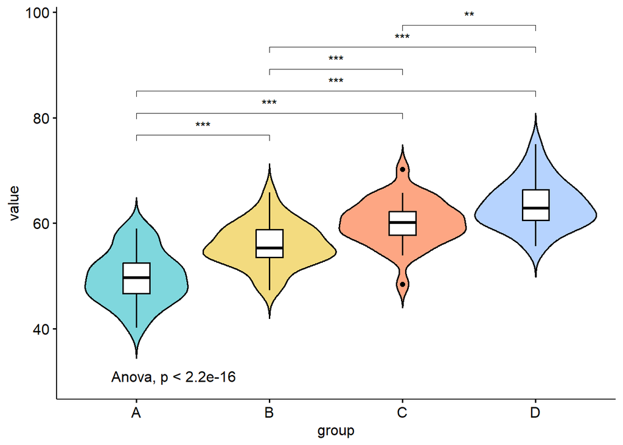

```r
# 加载包
library(ggplot2)
library(ggpubr)

# 设定显著性水平α=0.05
a <- 0.05

# 生成四组数据
set.seed(123)
groupA <- rnorm(30, mean = 50, sd = 5)
groupB <- rnorm(30, mean = 55, sd = 5)
groupC <- rnorm(30, mean = 60, sd = 5)
groupD <- rnorm(30, mean = 64, sd = 5)

# 数据框整理
dat <- data.frame(
  value = c(groupA, groupB, groupC, groupD),
  group = factor(rep(c("A", "B", "C", "D"), each = 30))
)

# 绘图
vars <- unique(dat$group) %>% as.vector()
varscomb <- combn(vars,2,simplify=F)
ggviolin(dat, x = "group", y = "value", fill = "group",
         palette = c("#00AFBB", "#E7B800", "#FC4E07", "#6EA8FD"), alpha=0.5,
         add = "boxplot", add.params = list(fill = "white"))+
  # 添加标记，有comparisons是成对的，方法包括t.test、wilcox.test（成对时不能用anova这种全局的）
  stat_compare_means(
    comparisons = varscomb,
    method = "wilcox.test",
    symnum.args = list(cutpoints = c(0, 0.001, 0.01, 0.05, Inf),
                       symbols = c("***", "**", "*", "NS")),
    label = "p.signif")+
  # 添加标记，没有comparisons是全局的，标记整体显著性，方法包括anova等（整体是不能用t.test这种成对的，会重叠）
  stat_compare_means(label.y = 30, method = "anova")+
  theme(legend.position = "none")
```

**（2）均值图（barplot或point）+误差（se或sd）+外部检验+显著性成对标记（星号或p值）**

此种情况，使用使用全部数据+统计变换（此处用ggpubr包免变换），区别与上面，这里用外部检验，稍微放宽了对ggpubr的依赖，可调参数稍多一些。

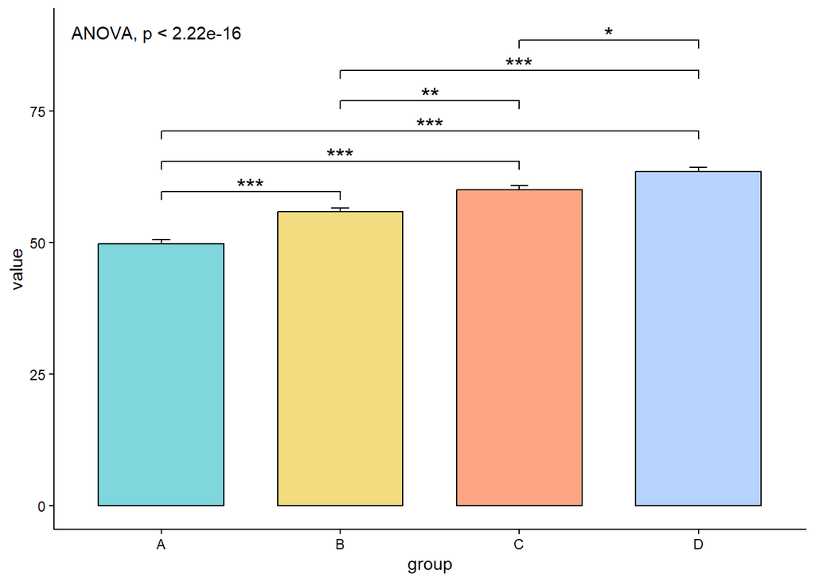

```r
# 加载包
library(ggplot2)
library(ggpubr)
# library(rstatix)
library(magrittr)

# 设定显著性水平α=0.05
a <- 0.05

# 生成四组数据
set.seed(123)
groupA <- rnorm(30, mean = 50, sd = 5)
groupB <- rnorm(30, mean = 55, sd = 5)
groupC <- rnorm(30, mean = 60, sd = 5)
groupD <- rnorm(30, mean = 64, sd = 5)

# 数据框整理
dat <- data.frame(
  value = c(groupA, groupB, groupC, groupD),
  group = factor(rep(c("A", "B", "C", "D"), each = 30))
)

# 统计检验（Wilcoxon秩和检验，Bonferroni校正）
stat.test <- dat %>%
  rstatix::wilcox_test(value~group, p.adjust.method = "bonferroni") %>%
  rstatix::add_xy_position(x = "group", data = dat, step.increase = 0.3)     #添加作图属性

# 修改显著性符号（等效于上面的symnum.args）
stat.test <- stat.test %>%
  dplyr::mutate(
    p.signif_manu = dplyr::case_when(
      p.adj < 0.001 ~ "***",
      p.adj < 0.01  ~ "**",
      p.adj < 0.05  ~ "*",
      TRUE          ~ "NS"  # 不显著
    )
  )

# 计算全局检验（ANOVA或Kruskal-Wallis）
global_p <- aov(Sepal.Length ~ Species, data = iris) %>% summary() %>% {.[[1]]["Pr(>F)"][1, 1]}
# global_p <- kruskal.test(Sepal.Length ~ Species, data = iris)$p.value

# 将p值格式化为文本（带方法名称）
formatted_p <- paste0("ANOVA, p",
                      ifelse(grepl("<", format.pval(global_p)), " ", " = "),
                      format.pval(global_p))

# 绘图
ggbarplot(dat, x = "group", y = "value", fill = "group",
          palette = c("#00AFBB", "#E7B800", "#FC4E07", "#6EA8FD"), alpha=0.5,
          add = "mean_se", error.plot = "upper_errorbar")+                     #ggplot没有upper_errorbar方法
  # 添加全局P值标记
  annotate("text", x=0.5, y=90, label=formatted_p, hjust=0)+
  # 添加配对显著性标记
  stat_pvalue_manual(
    stat.test,
    y.position = stat.test$y.position-20,  #整体下移20
    label = "p.signif_manu",               #label所在变量
    tip.length = 0.03,                     #括号（“连接线”）的两边长度（0=无横线）
    bracket.size = 0.5,                    #括号的线粗
    label.size = 5,                        #显著性标签（如 "***"）字体大小
    inherit.aes = FALSE                    #不继承主图的 aes 映射（自己指定的变量）
  )+
  theme_classic()+
  theme(legend.position = "none")
```

**（3）均值图（barplot或point）+误差（se或sd）+外部检验+显著性整体标记（字母）**

此种情况，使用使用全部数据+统计变换（此处用ggplot2包变换），这里使用ggplot2包，可调参数最多

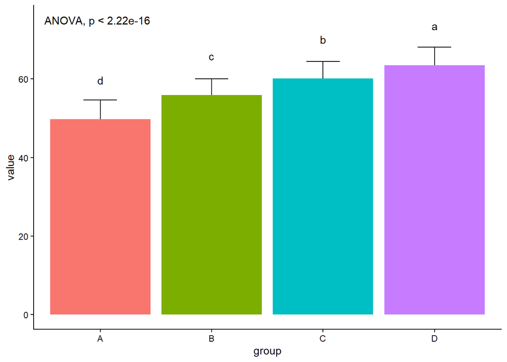

```r
# 加载包
library(ggplot2)
library(magrittr)
library(multcomp)
library(emmeans)

# 设定显著性水平α=0.05
a <- 0.05

# 生成四组数据
set.seed(123)
groupA <- rnorm(30, mean = 50, sd = 5)
groupB <- rnorm(30, mean = 55, sd = 5)
groupC <- rnorm(30, mean = 60, sd = 5)
groupD <- rnorm(30, mean = 64, sd = 5)

# 数据框整理
dat <- data.frame(
  value = c(groupA, groupB, groupC, groupD),
  group = factor(rep(c("A", "B", "C", "D"), each = 30))
)

# 字母显著性创建方法1，用multcomp::glht的Tukey方法，结果只是一个向量，如需绘图还得整理（不推荐）
# cld_result1 <- aov(value ~ group, data = dat) %>%
#   multcomp::glht(linfct = mcp(group = "Tukey")) %>%
#   multcomp::cld(decreasing = T)          #这里参数Letters = LETTERS不起作用

# 字母显著性创建方法2，用emmeans::emmeans的线性假设，结果可能与aov的Tukey不同，但是df型，可以直接用
cld_result2 <- aov(value ~ group, data = dat) %>%
  emmeans::emmeans(~ group) %>%
  # graphics::pairs(adjust = "tukey") %>%    #显式应用Tukey，不要加这句，否则就是成对的字母显著性标记
  multcomp::cld(Letters = letters, decreasing = T)
cld_result2$.group <- stringr::str_trim(cld_result2$.group)  #标记两侧有空格

# 计算全局检验（ANOVA或Kruskal-Wallis）
global_p <- aov(Sepal.Length ~ Species, data = iris) %>% summary() %>% {.[[1]]["Pr(>F)"][1, 1]}
# global_p <- kruskal.test(Sepal.Length ~ Species, data = iris)$p.value

# 将p值格式化为文本（带方法名称）
formatted_p <- paste0("ANOVA, p",
                      ifelse(grepl("<", format.pval(global_p)), " ", " = "),
                      format.pval(global_p))

# 绘图
ggplot(dat, aes(group, value, fill=group))+
  stat_summary(fun.data = ggpubr::mean_sd, geom = "errorbar", width=0.3)+       #ggplot2只能放在col下面以隐藏下半errorbar
  stat_summary(fun = mean, geom = "col", show.legend = F)+
  annotate("text", x=0.5, y=75, label=formatted_p, hjust=0)+
  geom_text(data = cld_result2, aes(y=emmean+10,label=.group))+
  theme_classic()
```

## 4.2 双因素标记

**（1）分布图（boxplot或violin）/均值误差图（barplot或point+se或sd）+外部检验+显著性分组标记（星号或p值）**

此种情况，自定义了一个标记函数，对分布或变换数据无要求，使用ggplot2，标记每个x轴对应组别内部的，关于分类变量之间的显著性

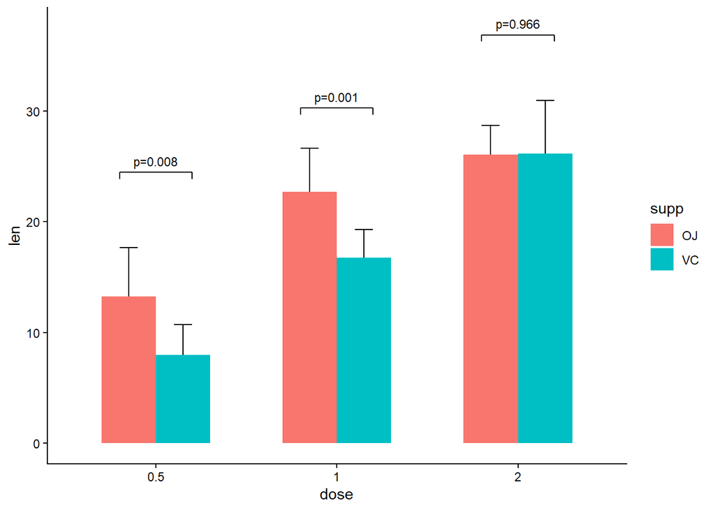

```r
# 加载包
library(magrittr)
library(data.table)
# library(rstatix)
library(ggplot2)
library(multcomp)
library(ggsci)
library(stringr)
library(magrittr)

# 设定显著性水平α=0.05
a <- 0.05

# 数据来自datasets
dat <- ToothGrowth
dat$dose <- factor(dat$dose)
dat$supp <- factor(dat$supp)

# 定义一个函数，生成双因素方差结果图的显著性成对标记图层
# 成对标记为，x轴方向+class分类变量，在doge形式上，标记每个x类别对应的class组间对比
pairs_sig_mark <- function(data, yn, xn, cn, xlength=0.4, ylengths=0.02, yheighs=0.1, theighs=0.02, is_pvalue=F,
                           p_dig=3, linewidth=0.5, size=4, ...){
  # data：绘图数据（在...中传递）
  # yn,xn,cn：分别是y轴、x轴、分类的变量所在列号，每个变量一个
  # xlength：横向标记线长度，绝对值
  # ylengths：竖向标记线（横向两端）长度乘数（长度为数据y范围*yscale），0-1之间
  # yheighs：横向标记线的高度位置尺度（高度为数据y最大值+y范围*yvscale），0-1之间
  # theighs：文字标记的高度位置尺度（高度为yvscale+范围*tvscale），0-1之间
  # is_pvalue：显著性标记p值还是星号
  # p_dig：p值小数位数，低于此精度p值显示小于号

  # 获取、定制数据基本信息
  setDT(data)
  ocolname <- names(data)
  sigdata <- data[, .SD, .SDcols = c(yn, xn, cn)] %>%
    set_colnames(c("yy","xx","cc"))
  xx_level <- unique(sigdata$xx)                      #x轴上分类个个数
  yrange <- range(sigdata$yy) %>% diff() %>% abs()    #y轴范围尺度，全局数据

  # 每组显著性，x轴变量的每组下，对class变量单独做单因素方差分析，提取结果
  p_value <- rep(0, length(xx_level))
  for(i in seq_along(xx_level)){
    p_value[i] <- sigdata[xx==xx_level[i], ] %>% rstatix::anova_test(yy~cc, white.adjust = T) %>% .[,"p"]
  }
  if(isTRUE(is_pvalue)) {                              #返回p值还是星号
    signal_text <- ifelse(p_value<10^(-p_dig), paste0("p<1e-",p_dig), sprintf(paste0("p=%.",p_dig,"f"),p_value))
  } else {
    signal_text <- ifelse(p_value <= 0.001, "***",
                          ifelse(p_value <= 0.01,  "**",
                                 ifelse(p_value <= 0.05,  "*", "NS")))
  }

  # 显著性标线数据，横向部分
  sigdata_x <- copy(sigdata) %>%
    .[,.(yymax=max(yy)+yrange*yheighs), by=c("xx")] %>%                  #指定横线y坐标
    .[, xcen:=1:length(xx_level)] %>%                                    #指定横线中心x坐标
    .[, c("xleft", "xright"):=list(xcen-xlength/2, xcen+xlength/2)]      #由中心向两端延伸出端点x坐标

  # 显著性标线数据，纵向部分
  sigdata_y <- copy(sigdata_x) %>%
    melt(id=c("xx", "yymax", "xcen"), value.name = "xendpoint") %>%      #指定竖线x坐标、上端y坐标（即yymax）
    .[, yymin:=yymax-yrange*ylengths]                                    #指定竖线下端y坐标

  # 显著性文字
  sigdata_text <- copy(sigdata_x) %>%
    .[,ycen:=yymax+yrange*theighs] %>%                                   #指定显著性文字y坐标
    .[,p_l:=signal_text]                                                 #指定显著性文字内容

  # 图层输出
  geom_list <- list(
    geom_linerange(data=sigdata_x, aes(y=yymax, xmin=xleft, xmax=xright), show.legend=F, inherit.aes=F, linewidth=linewidth, ...),
    geom_linerange(data=sigdata_y, aes(x=xendpoint, ymin=yymin, ymax=yymax), show.legend=F, inherit.aes=F, linewidth=linewidth, ...),
    geom_text(data=sigdata_text, aes(xcen, ycen, label=p_l), show.legend=F, inherit.aes=F, hjust=0.5, vjust=0, size=size, ...)
  )
  return(geom_list)
}

# 绘图
ggplot(data=dat, aes(dose, len, fill=supp))+
  # geom_violin(trim=F)+
  stat_summary(fun.data = ggpubr::mean_sd, geom="errorbar", width=0.2, position=position_dodge(width=0.6))+           #ggplot2中只有mean_sdl，其中为2*sd
  stat_summary(fun=mean, geom="col", width=0.6, position=position_dodge(width=0.6))+
  pairs_sig_mark(data=dat, yn=1,xn=3,cn=2, is_pvalue=T,linewidth=0.5,size=3)+
  theme_classic()
```

**（2）均值和误差（barplot或point+se或sd）+外部检验+显著性整体标记（字母）**

此种情况，使用使用全部数据+统计变换（此处用ggplot2包变换），这里使用ggplot2包，可调参数最多

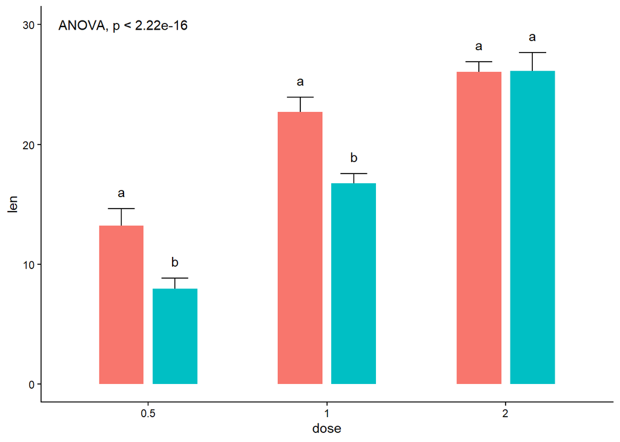

```r
# 加载包
library(magrittr)
library(data.table)
# library(rstatix)       #这个包会和其他包常用函数有冲突，如select、filter
library(ggplot2)
library(multcomp)
library(ggsci)
library(stringr)
library(magrittr)

# 设定显著性水平α=0.05
a <- 0.05

# 数据来自datasets
dat <- ToothGrowth
dat$dose <- factor(dat$dose)
dat$supp <- factor(dat$supp)

# 字母显著性创建方法2，用emmeans::emmeans的线性假设，结果可能与aov的Tukey不同，但是df型，可以直接用
cld_result_temp <- aov(len ~ supp*dose, data = dat) %>%          #注意这里需要考虑交互，否则结果不严谨
  emmeans::emmeans(~ supp|dose) %>%
  multcomp::cld(Letters = letters, decreasing = T) %>%
  setDT() %>%
  .[,.group:=stringr::str_trim(.group)]                         #标记两侧有空格

cld_result <- copy(dat) %>%
  setDT() %>%
  .[, .(se=sd(len)/sqrt(.N)), by=c("supp","dose")] %>%
  .[cld_result_temp, on=c("supp","dose")]

# 计算全局检验（ANOVA）
global_p <- aov(Sepal.Length ~ Species, data = iris) %>% summary() %>% {.[[1]]["Pr(>F)"][1, 1]}

# 将p值格式化为文本（带方法名称）
formatted_p <- paste0("ANOVA, p",
                      ifelse(grepl("<", format.pval(global_p)), " ", " = "),
                      format.pval(global_p))

# 绘图
pd <- position_dodge(width=0.6)
ggplot(dat, aes(dose, len, fill=supp))+
  stat_summary(fun.data = mean_se, geom = "errorbar", width=0.3, position = pd)+       #ggplot2只能放在col下面以隐藏下半errorbar
  stat_summary(fun = mean, geom = "col", width=0.5, position = pd, show.legend = F)+
  annotate("text", x=0.5, y=30, label=formatted_p, hjust=0)+
  geom_text(data = cld_result, aes(x=dose, y=emmean+se+1, label=.group), position = pd, hjust=0.5, vjust=0)+
  theme_classic()
```

## 4.3 自定义标记

早前写的，自定义函数版本，事先将数据汇总，并计算好显著性，然后画在图中，为了向bar图添加显著性标记，自定义了一个函数。

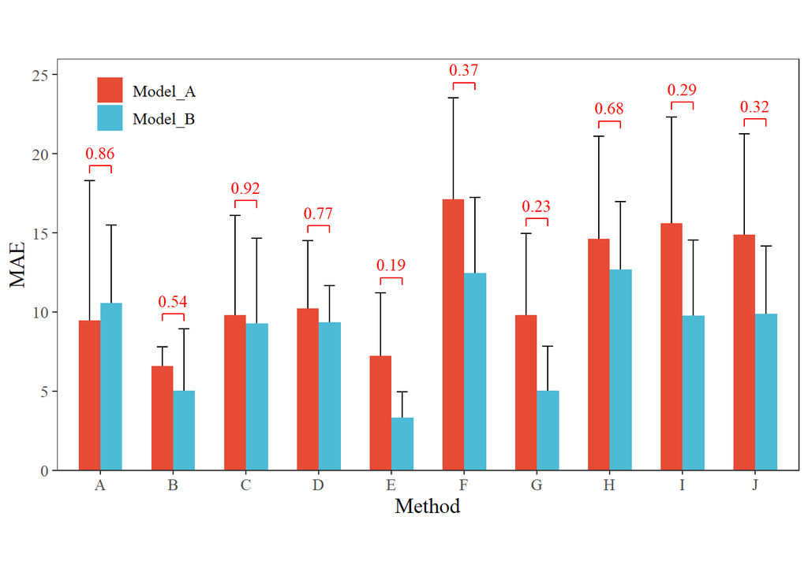

```r
# 加载所需包
library(magrittr)
library(data.table)
library(ggplot2)
library(multcomp)   #计算avo的pvalue
library(ggsci)
# library(ggsignif) #当画箱形图时，可用这个包

# 定义一个函数，生成均值方差和显著性标记线、标签（此处用的是方差分析）
data_material <- function(data, xdrift=0.15, ydrift=0.04, equleg=T){
  # xdrift和ydrift为xy方向偏移量，其中xdrift应为bar宽度width的一半，equleg设置标记的腿是否等长
  # 提取计算列，备份原列名，然后赋予新列名，便于后续计算
  con_data <- data[,1:3]
  ori_name <- colnames(con_data)
  names(con_data) <- c("xaxis", "compare", "value")

  #先按因子类型排序con_data
  setorder(con_data, xaxis, compare)

  # 生成均值、方差列
  data_msd <- con_data[, .(m=mean(value), sd=sd(value)), by=c("xaxis", "compare")]

  # 方差分析，生成p值显著性标签
  p.frame <- data.table(xaxis=unique(con_data$xaxis), p.value=NA_real_, p.label=NA_character_)
  for(i in p.frame$xaxis){
    tres <- aov(value~compare, con_data[xaxis==i,])
    tp <- glht(tres, linfct = mcp(compare = "Tukey")) %>% summary()
    p.frame[xaxis == i, p.value:=tp$test$pvalues]
    p.frame[xaxis == i, p.label:=ifelse(p.value<0.01, "***", ifelse(p.value<0.05, "**", ifelse(p.value<0.1, "*", "NS")))]
  }

  # 生成标记线图层
  data_msd[, msd:=m+sd]                      #添加一列，为mean+sd
  compare_lv1 <- levels(data_msd$compare)[1]
  compare_lv2 <- levels(data_msd$compare)[2]
  xcen <- seq_along(unique(data_msd$xaxis))  #x的中心位置，为fa1的变量个数
  xoff <- xdrift                             #x起止位置偏移量，为bar宽度的一半
  m_plus_sd <- data_msd[, max(msd), by=c("xaxis")]$V1
  unitdrift <- ydrift*max(m_plus_sd)           #全图中最大的mean+sd乘以偏移比，为单位偏移量
  ycen <- m_plus_sd+unitdrift                  #y中心位置，为m+sd加单位偏移量
  yleft <- data_msd[compare==compare_lv1, msd]+unitdrift*0.5 #左脚最低位置，为m+sd加0.5个单位偏移量
  yrigh <- data_msd[compare==compare_lv2, msd]+unitdrift*0.5 #右脚最低位置，为m+sd加0.5个单位偏移量
  if(isTRUE(equleg)) yleft <- yrigh <- pmax(yleft,yrigh)     #如果相同，则取最大的那个

  # 生成标记线和标签数据，p值默认两位小数
  sig_seg <- data.table(x0=c(xcen-xoff, xcen-xoff, xcen+xoff), x1=c(xcen-xoff, xcen+xoff, xcen+xoff),
                        y0=c(yleft, ycen, ycen), y1=c(ycen, ycen, yrigh))
  sig_lab <- data.table(x=xcen, y=ycen+unitdrift*0.5, p.value=sprintf("%.2f", p.frame$p.value), p.label=p.frame$p.label)

  # 恢复数据列名
  names(data_msd) <- c(ori_name[1:2], "m", "sd","msd")
  names(p.frame) <- c(ori_name[1], "p.value", "p.label")

  # 输出结果
  res <- list(data.msd=data_msd, sig.segment=sig_seg, sig.label=sig_lab)
  return(res)
}

# 数据，第一列是x轴，第二列是对比类（只有两类），第三列是数据
# 其中，第一、二列必须是因子型，顺序是已定义的
data <- data.table(method = c('B', 'B', 'B', 'A', 'A', 'A', 'C', 'C', 'C', 'D', 'D', 'D',
                              'E', 'E', 'E', 'F', 'F', 'F', 'G', 'G', 'G', 'H', 'H', 'H',
                              'I', 'I', 'I', 'J', 'J', 'J', 'B', 'B', 'B', 'A', 'A', 'A',
                              'C', 'C', 'C', 'D', 'D', 'D', 'E', 'E', 'E', 'F', 'F', 'F',
                              'G', 'G', 'G', 'H', 'H', 'H', 'I', 'I', 'I', 'J', 'J', 'J'),
                   model = c('B', 'B', 'B', 'B', 'B', 'B', 'B', 'B', 'B', 'B', 'B', 'B', 'B',
                             'B', 'B', 'B', 'B', 'B', 'B', 'B', 'B', 'B', 'B', 'B', 'B', 'B',
                             'B', 'B', 'B', 'B', 'A', 'A', 'A', 'A', 'A', 'A', 'A', 'A', 'A',
                             'A', 'A', 'A', 'A', 'A', 'A', 'A', 'A', 'A', 'A', 'A', 'A', 'A',
                             'A', 'A', 'A', 'A', 'A', 'A', 'A', 'A'),
                   MAE = c(9.04, 1.20, 4.80, 16.24, 7.80, 7.63, 15.38, 7.33, 5.10, 10.14,
                           6.77, 11.20, 2.49, 5.20, 2.33, 15.78, 7.00, 14.63, 8.18, 2.73,
                           4.13, 16.18, 7.87, 13.97, 14.51, 4.93, 9.87, 14.44, 5.93, 9.30,
                           7.60, 5.24, 6.94, 19.08, 7.59, 1.69, 16.95, 7.39, 5.09, 14.59,
                           6.03, 10.08, 8.66, 10.31, 2.71, 23.00, 10.28, 18.10, 15.75, 7.13,
                           6.50, 20.84, 7.90, 15.17, 21.33, 8.25, 17.28, 20.63, 8.07, 15.99))
method_lev <- c("A","B","C","D","E","F","G","H","I","J")
model_lev <- c("A", "B")
data[, method:=factor(method, levels = method_lev)]
data[, model:=factor(model, levels = model_lev)]

# 生成均值方差、和显著性数据
res <- data_material(data)
data_msd <- res$data.msd
sig_seg <- res$sig.segment
sig_lab <- res$sig.label

# 画图
ggplot(data_msd, aes(method, m, fill = model))+
  geom_errorbar(aes(ymin= m-sd, ymax=m+sd), position = position_dodge(0.6), width = 0.3)+
  geom_bar(stat = "identity", position = position_dodge(), width = 0.6)+
  scale_fill_npg(labels = c("Model_A", "Model_B"))+
  geom_segment(data = sig_seg, aes(x=x0, xend=x1, y=y0, yend=y1, fill=NULL), color="red")+
  geom_text(data=sig_lab, aes(x=x, y=y, label=p.value, fill=NULL), color="red", vjust=0, family = "serif")+    #可选，显示p值
  # geom_text(data=sig_lab, aes(x=x, y=y, label=p.label, fill=NULL), color="red", vjust=0, family = "serif")+  #可选，显示显著性符号
  scale_y_continuous(limits = c(0, 26), expand = c(0,0))+
  guides(fill = guide_legend(title = NULL))+
  labs(x = "Method", y = "MAE")+
  theme_bw()+
  theme(aspect.ratio = 1/1.8,
        axis.text = element_text(size = 10, family = "serif"),
        axis.title = element_text(size = 13, family = "serif"),
        text = element_text(family = "serif"),
        panel.grid = element_blank(),
        legend.text = element_text(size = 10),
        legend.position = c(0.12, 0.89),
        plot.title = element_text(hjust = 0.5))
```

## 4.3. 堆叠误差线图

一个只有堆叠误差线的图，修改自网上的一个案例，具体来源记不清了。

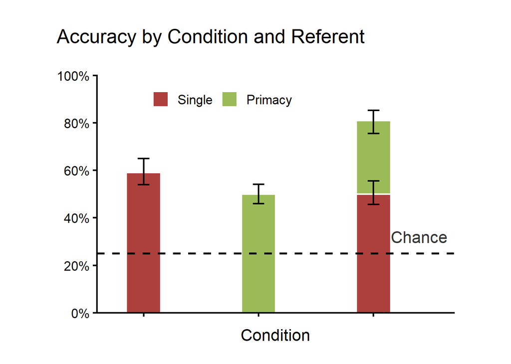

```r
# 加载包
library(ggplot2)
library(data.table)

# 数据
df <- data.table(Condition=c(1,1,2,2,3,3,3),
                   Referent=c('Single','Primacy','Single','Recency','Single','Primacy','Recency'),
                   Accuracy=c(0.63,0.59,0.63,0.5,0.63,0.5,0.31),
                   error_low=c(0.04,0.05,0.057,0.04,0.041,0.043,0.055),
                   error_high=c(0.055,0.059,0.049,0.041,0.053,0.055,0.043),
                   Condition_name=c('Primacy','Primacy','Recency','Recency','Both','Both','Both'),
                   left=c(TRUE,FALSE,TRUE,FALSE,TRUE,FALSE,FALSE),
                   color=c('#29476B','#AD403D','#29476B','#9BBB58','#29476B','#AD403D','#9BBB58'))
df2 <- df[left==F,]

# 绘图
ggplot(df2,aes(x = Condition, y = Accuracy, fill = color)) +
  geom_col(data = df2, color = "white", width = .3,)+
  geom_errorbar(
    aes(y = y, ymin = y - error_low, ymax = y + error_high),
    data = df2[left==F, y:=cumsum(Accuracy), by="Condition"],
    width = .1
  ) +
  geom_hline(aes(yintercept = .25), linetype = 2, size = 1) +
  annotate("text", x = 3.4, y = .32, label = "Chance", color = "grey20") +
  scale_fill_identity(labels = c("Single", "Primacy"), guide = guide_legend(title = NULL, direction = "horizontal", override.aes = list(fill = c("#AD403D", "#9BBB58")))) +    #这里图层中已经没有Single了，只有两个color
  # scale_x_continuous(breaks = 1:3 - .15, labels = levels(df$Condition_name), expand = expansion(c(.1, .05))) +   #这个代码修改了横坐标对齐方式，结果会偏离，并不好看
  scale_x_continuous(breaks = 1:3, labels = levels(df$Condition_name), expand = c(0.1,0,0,0.3)) +
  scale_y_continuous(breaks = scales::pretty_breaks(6), labels = scales::percent_format(1), limits = 0:1, expand = expansion(0)) +
  labs(title = "Accuracy by Condition and Referent", y = NULL) +
  theme_classic(base_size = 16) +
  theme(aspect.ratio = 1/1.5,
        plot.title.position = "plot",
        plot.title = element_text(margin = margin(0, 0, 1, 0, "cm")),
        legend.position = c(.35, .9),
        axis.title.x = element_text(margin = margin(t = .4, unit = "cm")),
        plot.margin = margin(1, 1, .7, 1, "cm"))
```

# 5. 全球气温变化图

尝试实现和[NOAA Global Time Series](https://www.ncei.noaa.gov/access/monitoring/climate-at-a-glance/global/time-series/globe/land_ocean/12/12/1959-2022?trend=true&trend_base=100&begtrendyear=1959&endtrendyear=2022)相似但是静态的图

注意coord_cartesian(clip=“off”)的作用，控制仅在边框处的点线，是否进行裁切，并不能让点线画在绘图区域以外，而对于文字，同一个文字图层可以跨过绘图区域而不被裁掉。至于legend，即使没有设置这个，也可以放在绘图区域外，通过负数或大于1的数即可。

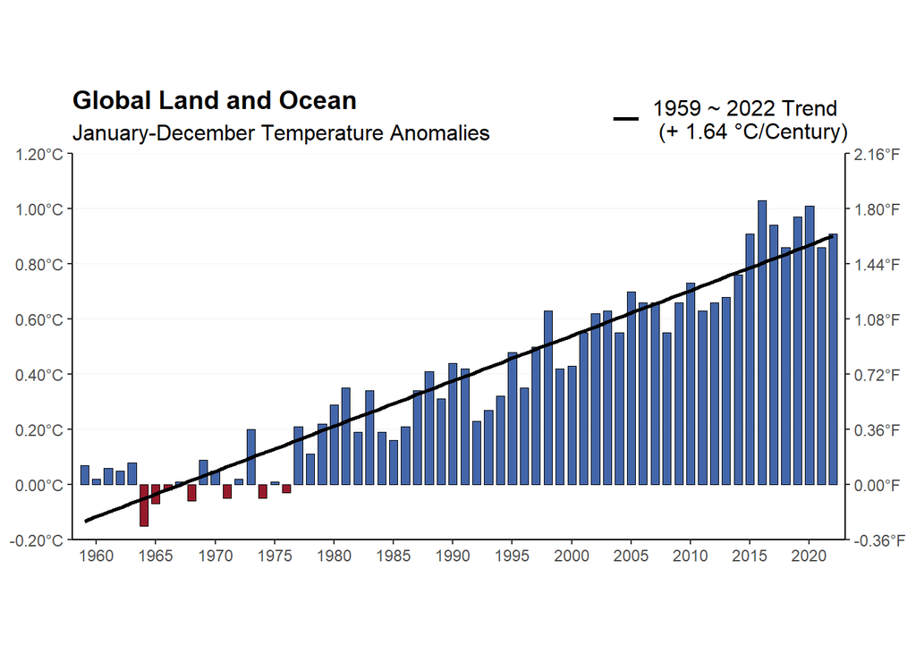

```r
# 加载包
library(ggplot2)
library(data.table)

# 生成数据
dat <- data.table(Year = c(1959, 1960, 1961, 1962, 1963, 1964, 1965, 1966, 1967, 1968, 1969, 1970, 1971, 1972, 1973, 1974, 1975, 1976, 1977, 1978, 1979, 1980, 1981, 1982, 1983, 1984, 1985, 1986, 1987, 1988, 1989, 1990, 1991, 1992, 1993, 1994, 1995, 1996, 1997, 1998, 1999, 2000, 2001, 2002, 2003, 2004, 2005, 2006, 2007, 2008, 2009, 2010, 2011, 2012, 2013, 2014, 2015, 2016, 2017, 2018, 2019, 2020, 2021, 2022), CO2 = c(315.98, 316.91, 317.64, 318.45, 318.99, 319.62, 320.04, 321.37, 322.18, 323.05, 324.62, 325.68, 326.32, 327.46, 329.68, 330.19, 331.13, 332.03, 333.84, 335.41, 336.84, 338.76, 340.12, 341.48, 343.15, 344.87, 346.35, 347.61, 349.31, 351.69, 353.2, 354.45, 355.7, 356.54, 357.21, 358.96, 360.97, 362.74, 363.88, 366.84, 368.54, 369.71, 371.32, 373.45, 375.98, 377.7, 379.98, 382.09, 384.02, 385.83, 387.64, 390.1, 391.85, 394.06, 396.74, 398.81, 401.01, 404.41, 406.76, 408.72, 411.66, 414.24, 416.45, 418.56), Value = c(0.07, 0.02, 0.06, 0.05, 0.08, -0.15, -0.07, -0.02, 0.01, -0.06, 0.09, 0.05, -0.05, 0.02, 0.2, -0.05, 0.01, -0.03, 0.21, 0.11, 0.22, 0.29, 0.35, 0.19, 0.34, 0.19, 0.16, 0.21, 0.34, 0.41, 0.31, 0.44, 0.42, 0.23, 0.27, 0.32, 0.48, 0.35, 0.5, 0.63, 0.42, 0.43, 0.55, 0.62, 0.63, 0.55, 0.7, 0.66, 0.66, 0.55, 0.66, 0.73, 0.63, 0.66, 0.68, 0.76, 0.91, 1.03, 0.94, 0.86, 0.97, 1.01, 0.86, 0.91))
dat[, col:=ifelse(Value>0,"b","r")]

# 画图
ggplot(dat,aes(Year, Value))+
  geom_bar(aes(fill=col), color="black", width=0.7, linewidth=0.1, stat = "identity", show.legend = F)+
  geom_smooth(aes(linetype = "l"), color="black", formula = y~x, se = F, method = "lm")+
  # geom_hline(yintercept = 0)+
  scale_x_continuous(breaks = seq(1960, 2022, by=5), limits = c(1958, 2023),expand = c(0,0))+
  scale_y_continuous(limits = c(-0.2,1.2),
                     breaks = seq(-0.20, 1.20, by=0.2),
                     expand = c(0,0),
                     labels=sprintf("%.2f\u00B0C",seq(-0.20, 1.20, by=0.2)),
                     sec.axis = sec_axis(transform  = ~.*1.8, #纵坐标为温度差值，所以只*1.8
                                         breaks = seq(-0.36,2.16, by=0.36),
                                         labels=sprintf("%.2f\u00B0F",seq(-0.36,2.16, by=0.36))))+
  scale_fill_manual(values = c("b"="#4366AA", "r"="#961A2B"))+
  scale_linetype_discrete(labels = c("l" = "1959 ~ 2022 Trend \n (+ 1.64 °C/Century)"))+
  guides(linetype = guide_legend(title = NULL))+
  labs(x=NULL, y = NULL,
       title="Global Land and Ocean",
       subtitle = "January-December Temperature Anomalies")+
  # coord_cartesian(clip = "off") +
  theme_bw()+
  theme(aspect.ratio = 1/2,
        axis.line = element_line(),
        panel.border = element_blank(),
        panel.grid.minor = element_blank(),
        panel.grid.major.x = element_blank(),
        panel.grid.major = element_line(color = "gray97"),
        plot.title = element_text(face = "bold", size = 14, hjust = 0),
        plot.subtitle = element_text(size = 12, hjust = 0),
        legend.position = "inside",
        legend.position.inside = c(0.85,1.09),
        legend.background = element_blank(),
        legend.text = element_text(size = 12)
  )
```

# 6. 流域岩石风化碳汇强度

这个图注意，离散坐标系实际也是连续的，若要在其中添加线，可以用序号加0.5添加在这两个bar之间

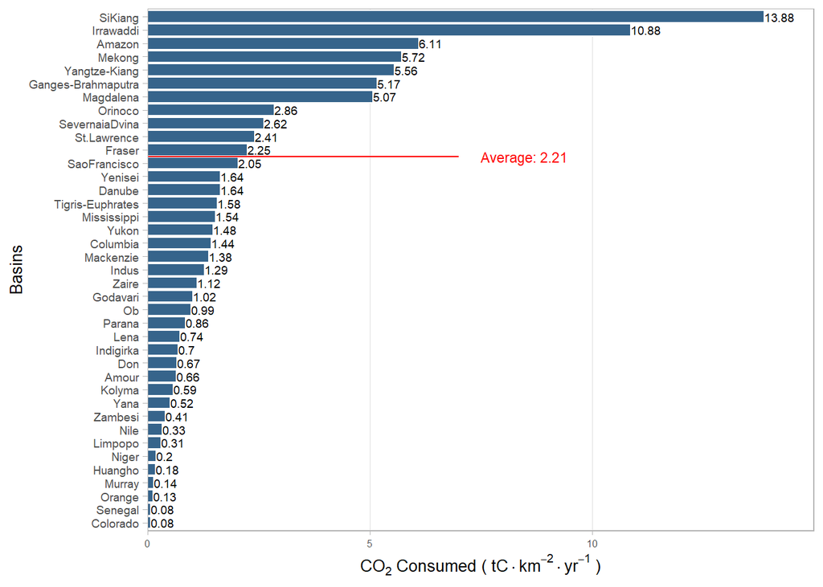

```r
# 加载包
library(ggplot2)
library(data.table)

# 数据
data <- data.table(Basin = c('SiKiang', 'Irrawaddi', 'Amazon', 'Mekong', 'Yangtze-Kiang',
                             'Ganges-Brahmaputra', 'Magdalena', 'Orinoco', 'SevernaiaDvina',
                             'St.Lawrence', 'Fraser', 'SaoFrancisco', 'Danube', 'Yenisei',
                             'Tigris-Euphrates', 'Mississippi', 'Yukon', 'Columbia',
                             'Mackenzie', 'Indus', 'Zaire', 'Godavari', 'Ob', 'Parana',
                             'Lena', 'Indigirka', 'Don', 'Amour', 'Kolyma', 'Yana',
                             'Zambesi', 'Nile', 'Limpopo', 'Niger', 'Huangho', 'Murray',
                             'Orange', 'Senegal', 'Colorado'),
                   x = c(13.88, 10.88, 6.11, 5.72, 5.56, 5.17, 5.07, 2.86, 2.62,
                         2.41, 2.25, 2.05, 1.64, 1.64, 1.58, 1.54, 1.48, 1.44, 1.38,
                         1.29, 1.12, 1.02, 0.99, 0.86, 0.74, 0.7, 0.67, 0.66, 0.59,
                         0.52, 0.41, 0.33, 0.31, 0.2, 0.18, 0.14, 0.13, 0.08, 0.08))

# 绘图
ggplot(data, aes(reorder(Basin, x), x, label = x))+
  geom_bar(stat = 'identity', fill = 'steelblue4', color = 'white')+
  geom_text(stat = 'identity', hjust = 0, vjust = 0.5, size = 2.5)+
  geom_segment(aes(x = 28.5, y = 0, xend = 28.5, yend = 7), color = "red", linewidth = 0.5)+
  annotate("text",x=28.5, y=7.5, label = "Average: 2.21", hjust = 0, size = 3, color = "red")+
  scale_y_continuous(expand = expansion(mult = c(0,0.08)))+
  labs(x = 'Basins', y = expression(CO[2] ~ "Consumed (" ~ tC%.%km^-2%.%yr^-1 ~ ")"))+
  coord_flip()+
  theme_light()+
  theme(axis.text = element_text(size = 6),
        axis.text.y = element_text(size = 7),
        axis.title = element_text(size = 10),
        panel.grid.minor = element_blank(),
        panel.grid.major.y = element_blank())
```

# 7. 在映射处使用字符类型

一般情况下ggplot函数，在美学影射aes处，要么用数据框+列名，如`ggplot(mpg,aes(displ, hwy))`；或者不用数据框直接用变量，如`ggplot(data=NULL,aes(1:3,4:6))`。

但是当对一个数据框中的多列或不特定列绘图时，可能会用到字符型变量作为美学影射。此时可以用以下方法实现：

1. aes_string()
2. aes()+!!sym()
3. aes()+str2expression()+eval()
4. aes()+.data[[]] #推荐方法

如果用color或fill映射，但是变量可能为空，可以用条件语句进行判断

```r
library(ggplot2)
a <- "displ"
b <- "hwy"
d <- "drv"
d <- c()   #测试空字符是否可以正常运行

# aes_string(), 虽然可行并且对空字符也能适应，但是已被ggplot2弃用，会出warning
# ggplot(mpg, aes_string(a,b, color=d))+
#   geom_point()

# 1.aes()+get()+
# ggplot(mpg, aes(get(a), get(b), color=if(!is.null(d)) get(d)))+
#   geom_point()+
#   labs(x=a, y=b, color=d)

# 2.aes()+!!sym()
# ggplot(mpg, aes(!!sym(a), !!sym(b), color=!!sym(d)))+
#   geom_point()

# 3.aes()+str2expression()+eval()
# ggplot(mpg, aes(eval(str2expression(a)), eval(str2expression(b)), color=eval(str2expression(d))))+
#   geom_point()+
#   labs(x=a, y=b)+
#   guides(color=guide_legend(title=d))

# 4.aes()+.data[[]]
# ggplot(mpg)+
#   geom_point(aes(.data[[a]], .data[[b]], color=if(is.null(d)) NULL else .data[[d]]))+
#   labs(color=d)
```

# 8. 特定类型图

## 8.1 地图

R画地图，需要注意的问题：

1. 画地图，主要是底图数据+展示数据（点、填充等）
2. 画底图主要有两种方式，一个是ggplot包，另一个是sf包
3. 底图数据主要来自R包如ggplot2、maps、rnaturalearth等，以及外部shap、JSON等文件
4. 注意在R包中，很多自带的底图数据，往往不符合中国法律，如没有南海、台湾等地区，所以谨慎使用

### 8.1.1 ggplot2

ggplot2数据、ggplot2绘图

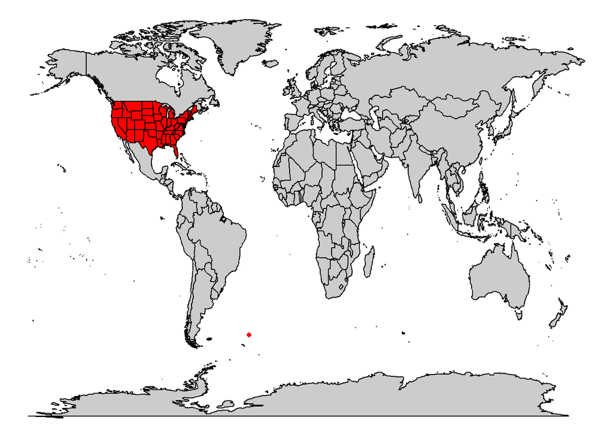

```r
# 所需包
library(ggplot2)

# 数据
mapdata <- map_data("world")   #世界地图
usadata <- map_data("state")   #美国地图
# 如果不知道如何调用国家名，使用以下代码查看、定制国家
# mapdata$region %>% unique()
# country_map <- mapdata[mapdata$region=="Nauru", ]

# 画图
ggplot()+
  geom_polygon(data=mapdata, aes(x=long, y=lat, group=group), fill="gray80", colour="black")+
  geom_polygon(data=usadata, aes(x=long, y=lat, group=group), fill="red", colour="black")+
  geom_point(aes(-33, -50), color="red")+
  theme_void()
```

### 8.1.2 maps+sf

maps数据，sf绘图

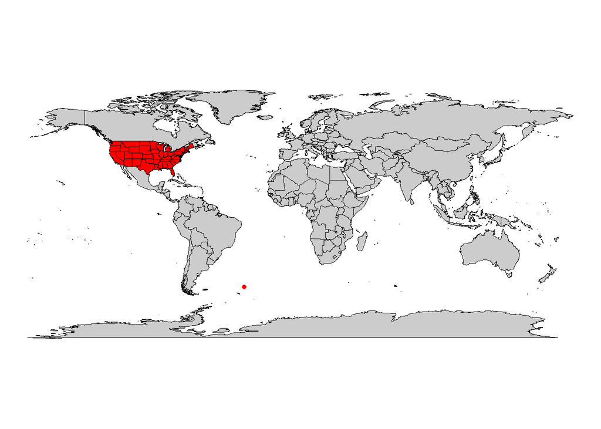

```r
# 所需包
library(ggplot2)
library(maps)
library(sf)

# 数据
# 这里如果使用ggplot2数据，则只有边界（线数据），内部是空的
mapdata_sf <- map("world", plot=FALSE, fill=TRUE) %>% st_as_sf(crs=4326)  #世界地图
usadata_sf <- map("state", plot=FALSE, fill=TRUE) %>% st_as_sf(crs=4326)  #美国地图
# 如果不知道如何调用国家名，使用以下代码查看、定制国家
# world_names <- map("world", plot = FALSE, fill = TRUE)$names
# country_map <- map("world", regions = "Aruba", plot = FALSE, fill = TRUE)

# 画图
ggplot()+
  geom_sf(data=mapdata_sf, fill="gray80", colour="black")+
  geom_sf(data=usadata_sf, fill="red", colour="black")+
  geom_point(aes(-33, -50), color="red")+
  theme_void()
```

### 8.1.3 rnaturalearth+sf

rnaturalearth数据、sf绘图

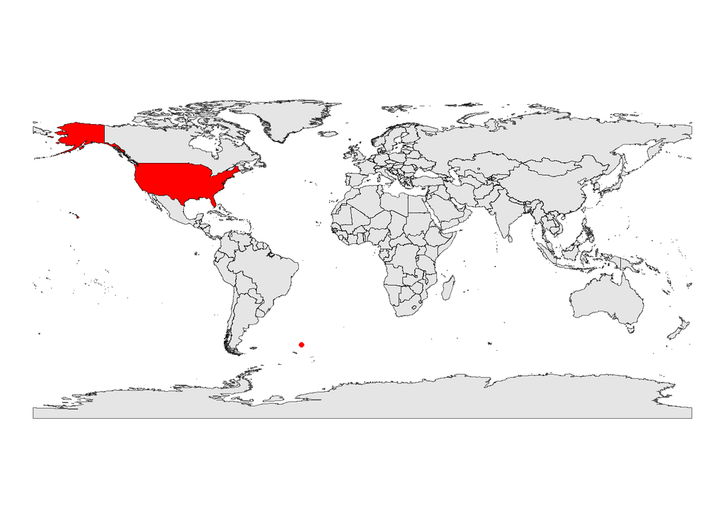

```r
# 加载包
library(ggplot2)
library(sf)
library(rnaturalearth)
# library(rnaturalearthdata)   #这两个包虽然不用加载，但是仍需要安装
# library(rnaturalearthhires)

# 数据
mapdata_rn <- ne_countries(scale = "large", returnclass = "sf")
usadata_rn <- ne_countries(country = "United States of America")
# 如果不知道如何调用国家名，使用以下代码查看
# mapdata_rn$name

# 画图
ggplot()+
  geom_sf(data = mapdata_rn)+
  geom_sf(data = usadata_rn, fill="red")+
  geom_point(aes(-33, -50), color="red")+
  theme_void()
```

### 8.1.4 外部数据+sf

底图数据下载：

- 天地图（中国自然资源部），中国省市县geogson文件：https://cloudcenter.tianditu.gov.cn/administrativeDivision
- 阿里云，中国国、省、市三级geojson文件：https://datav.aliyun.com/portal/school/atlas/area_selector
- 公众号，中国标准地图，审图号GS(2020)4619号，国、省、市、县等shpe文件：https://mp.weixin.qq.com/s/xFg_Q1C3Qeniwh4EDJhb3w

使用geojson数据，画一个中国省级虚拟数据的地图

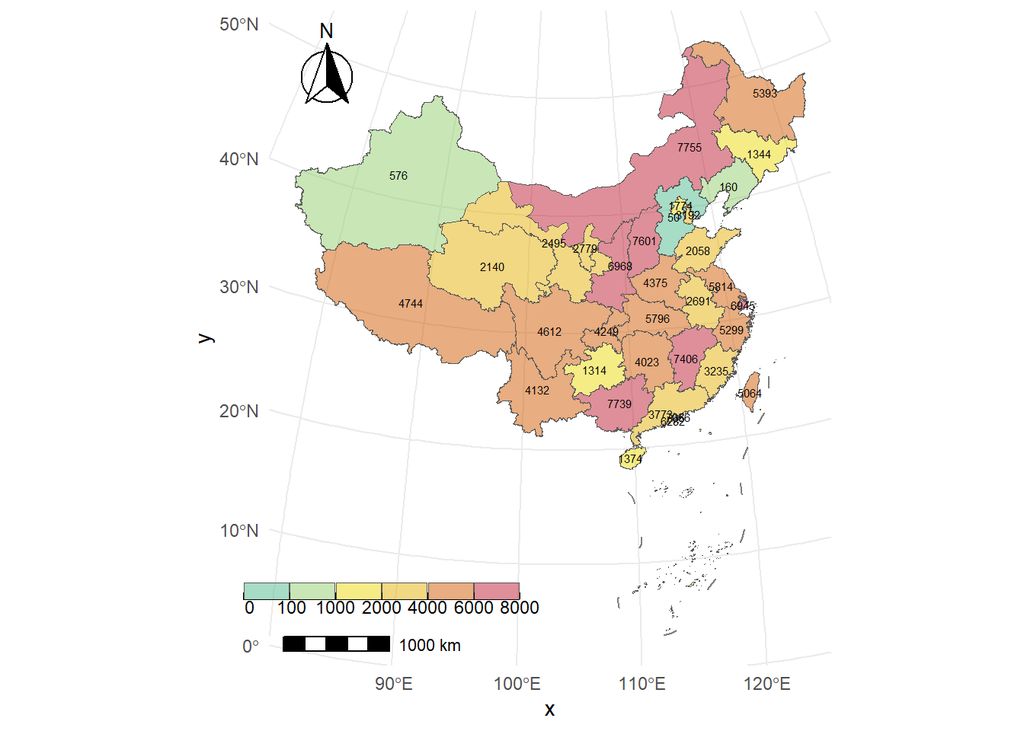

```r
# 加载包
library(ggplot2)
library(sf)
library(data.table)
library(ggspatial)   #添加比例尺、指北针

# 读取geojson数据
map_geojson <- read_sf("d:/#R/learn_visualization/data/mapdata/tianditu_china_1_province.geojson")

# 定义一个虚拟数据
prov_name <- map_geojson$name %>% unique() %>% setdiff("境界线")
data <- data.table(name=prov_name, value=round(runif(length(prov_name), 0, 8000)))

# 合并数据
data_plot <- dplyr::left_join(map_geojson, data, by="name") %>%
  dplyr::mutate(value_class=cut(value, breaks = c(0, 100, 1000, 2000, 4000, 6000, 8000)))

# 自定义颜色和标签
cust_colo <- c("#50b98f", "#92ce6e", "#edda0e", "#e5b107", "#d25c02", "#c01f33")
cust_labe <- c("(0,100]", "(100,1000]", "(1000,2000]", "(2000,4000]", "(4000,6000]", "[6000,8000]")

# 画图
ggplot(data_plot) +
  geom_sf(aes(fill=value_class), alpha=0.5)+
  geom_sf_text(aes(label = value), size=2) +
  # scale_fill_manual(values = cust_colo, label=cust_labe, na.translate = FALSE)+
  labs(fill="value")+
  coord_sf(crs = "+proj=laea +lat_0=40 +lon_0=104") +              #设定投影为LAEA、经纬中心点为40,104
  annotation_scale(location = "bl") +                              #添加比例尺t/b上下、l/r左右
  annotation_north_arrow(location = "tl", which_north = "false",   #网格北，而非真北
                         style = north_arrow_fancy_orienteering) + #指北针样式
  scale_fill_manual(name=NULL,
                    values = cust_colo,
                    guide = guide_bins(axis = FALSE,
                                       ticks=F,
                                       direction = "horizontal",
                                       show.limits = TRUE,
                                       keywidth = unit(0.8, 'cm'),
                                       keyheight = unit(0.3, 'cm'),
                                       nrow = 1),
                    na.translate = FALSE) +
  theme_minimal() +
  theme(plot.background = element_rect(fill = "white", color = NA),
        legend.position = "inside",
        legend.position.inside = c(0.2, 0.1),
        legend.key.spacing = unit(0, "cm"),
        legend.box.margin = unit(c(0,0,0,0), "cm")
  )
```

使用shape数据，画一个中国县级市虚拟数据的地图

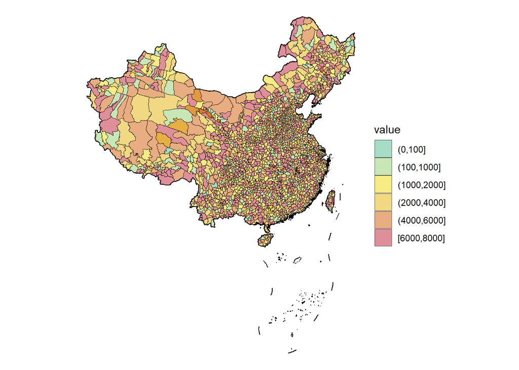

```r
# 加载包
library(ggplot2)
library(sf)
library(data.table)

# 读取 Shapefile 文件
map_shape   <- st_read("d:/#R/learn_visualization/data/mapdata/shape_GS(2020)4619/china_county.shp")
countryline <- st_read("d:/#R/learn_visualization/data/mapdata/shape_GS(2020)4619/china_outline.shp")

# 定义一个虚拟数据
prov_name <- map_shape$NAME
data <- data.table(NAME=prov_name, value=round(runif(length(prov_name), 0, 8000)))

# 合并数据
data_plot <- dplyr::left_join(map_shape, data, by="NAME") %>%
  dplyr::mutate(value_class=cut(value, breaks = c(0, 100, 1000, 2000, 4000, 6000, 8000)))

# 自定义颜色和标签
cust_colo <- c("#50b98f", "#92ce6e", "#edda0e", "#e5b107", "#d25c02", "#c01f33")
cust_labe <- c("(0,100]", "(100,1000]", "(1000,2000]", "(2000,4000]", "(4000,6000]", "[6000,8000]")

# 画图
ggplot() +
  geom_sf(data=data_plot, aes(fill=value_class), alpha=0.5)+
  geom_sf(data=countryline)+
  scale_fill_manual(values = cust_colo, label=cust_labe, na.translate = FALSE)+
  labs(fill="value")+
  theme_void()
```

### 8.1.5 TIF数据

代码修改自知乎文章

作者：顶刊美图社

链接：https://zhuanlan.zhihu.com/p/1893458482449061586

这里TIF文件来自github，https://github.com/nvkelso/natural-earth-raster，本质上是naturealearth的数据，但是由于过大，绘图会非常慢，所以这里只放代码，然后放一个绘图效果的png算了

1. 世界地图

```r
# 加载包
library(ggspatial)
library(stars)
library(data.table)
library(ggplot2)
# 添加字体支持
# showtext_auto()

# Sampling points in the world---------------------------------------------------------------
cities <- data.table(
  city = c("Beijing", "Shanghai", "Guangzhou", "Chengdu", "Shenzhen", "New York", "Los Angeles",
           "Chicago", "Houston", "Phoenix", "London", "Paris", "Berlin", "Madrid", "Rome", "Moscow",
           "Tokyo", "Seoul", "Sydney", "Toronto", "Mexico City", "São Paulo","Buenos Aires", "Cairo",
           "Istanbul", "Mumbai", "Delhi", "Jakarta", "Bangkok", "Singapore", "Johannesburg", "Nairobi",
           "Cape Town", "Melbourne", "Perth", "San Francisco", "Miami", "Boston", "Vancouver", "Montreal",
           "Rio de Janeiro", "Lima", "Bogotá", "Santiago", "Caracas", "Lisbon", "Amsterdam", "Brussels",
           "Vienna", "Zurich", "Warsaw", "Prague", "Budapest", "Dublin", "Stockholm", "Oslo", "Helsinki",
           "Copenhagen", "Athens", "Bratislava","Luxembourg", "Monaco", "Andorra la Vella", "Ljubljana", "Vilnius"),
  country = c("China", "China", "China", "China", "China", "USA", "USA", "USA", "USA", "USA", "UK",
              "France", "Germany", "Spain", "Italy", "Russia", "Japan", "South Korea", "Australia",
              "Canada", "Mexico", "Brazil", "Argentina", "Egypt", "Turkey", "India", "India",
              "Indonesia", "Thailand", "Singapore", "South Africa", "Kenya", "South Africa", "Australia",
              "Australia", "USA", "USA", "USA", "Canada", "Canada", "Brazil", "Peru", "Colombia", "Chile",
              "Venezuela", "Portugal", "Netherlands", "Belgium", "Austria", "Switzerland", "Poland",
              "Czech Republic", "Hungary", "Ireland", "Sweden", "Norway", "Finland", "Denmark", "Greece",
              "Slovakia", "Luxembourg", "Monaco", "Andorra", "Slovenia", "Lithuania"),
  latitude = c(39, 31, 23, 30, 22, 40, 34, 41, 29, 33, 51, 48, 52, 40, 41, 55, 35, 37, -33, 43, 19, -23, -34, 30, 41,
               19, 28, -6, 13, 1, -26, -1, -34, -37, -31, 37, 25, 42, 49, 45, -22, -12, 4, -33, 10, 38, 52, 50, 48, 47,
               52, 50, 47, 53, 59, 59, 60, 55, 37, 48, 49, 43, 42, 46, 54),
  longitude = c(116, 121, 113, 104, 114, -74, -118, -87, -95, -112, -0, 2, 13, -3, 12, 37, 139, 127, 151, -79,
                -99, -46, -58, 31, 29, 72, 77, 106, 100, 103, 28, 36, 18, 144, 115, -122, -80, -71, -123, -73,
                -43, -77, -74, -70, -66, -9, 4, 4, 16, 8, 21, 14, 19, -6, 18, 10, 25, 12, 23, 17, 6, 7, 1, 14, 25),
  group = sample(c("A", "B", "C", "D"), 65, replace = TRUE)
)

cities$group <- factor(cities$group,
                       levels = c("A", "B", "C", "D"),
                       labels = c("No HCN cline", "Positive HCN cline", "Negative HCN cline", "Genomic data sampled"))
df_st_as_sf <- st_as_sf(cities,
                        coords = c("longitude", "latitude"),
                        crs = 4326)

# 地图数据
nat.earth <- raster::brick("NE1_50M_LC_SR_W.tif", aggregate = 100)

# 绘图
ggplot(df_st_as_sf)+
  layer_spatial(nat.earth)+
  theme_bw()+
  geom_sf(mapping = aes(fill = group), shape = 21, size = 2) +
  scale_fill_manual(values = c("grey60","#E50F04","#2B799F","#753f93")) +
  guides(fill = guide_legend(override.aes = list(size = 3))) +
  # annotation_north_arrow(location = "tl", which_north = F,
  #                        pad_x = unit(0.03, "in"),
  #                        pad_y = unit(0.03, "in"),
  #                        style = north_arrow_fancy_orienteering) +
  theme(axis.text = element_text(size = 12, color = "black"),
        axis.line = element_blank(),
        legend.position = "inside",
        legend.position.inside = c(0.7,0.2),
        legend.title = element_blank(),
        panel.background = element_rect("#f5f6f1"),
        legend.key = element_rect(fill = "transparent"),
        legend.background = element_rect(fill = "transparent")
  )+
  #annotation_scale(location="bl",width_hint=0.3) +
  labs(x='', y='',color=NULL)
# ggsave("Word Map with Shaded Relief and Water.pdf", width = 9, height = 4.5)
```

绘图效果示例（运行绘图代码太过耗时）：

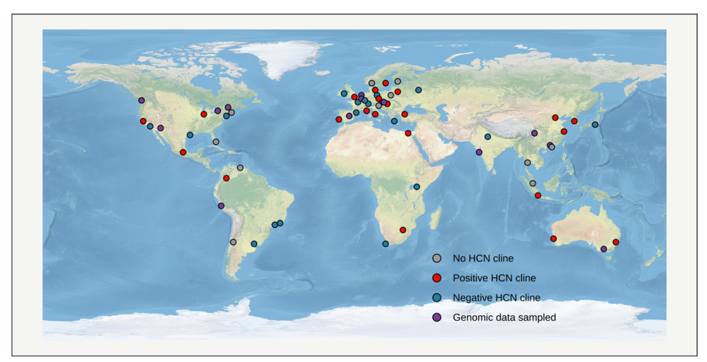

2. 中国地图：

```r
# 加载包
library(ggspatial)
library(stars)
library(data.table)
library(ggplot2)
# 添加字体支持
# showtext_auto()

# 数据
gdp2023 <- tidyr::tibble(
  province = c("北京市", "天津市", "河北省", "山西省", "内蒙古自治区",
               "辽宁省", "吉林省", "黑龙江省", "上海市", "江苏省",
               "浙江省", "安徽省", "福建省", "江西省", "山东省",
               "河南省", "湖北省", "湖南省", "广东省", "广西壮族自治区",
               "海南省", "重庆市", "四川省", "贵州省", "云南省",
               "西藏自治区", "陕西省", "甘肃省", "青海省", "宁夏回族自治区",
               "新疆维吾尔自治区","香港特别行政区","澳门特别行政区","台湾省"),
  gdp = c(43760.7, 16737.3, 43944.1, 25698.2, 24627,
          30209.4, 13531.2, 15883.9, 47218.7, 128222.2,
          82553.2, 47050.6, 54355.1, 32200.1, 92068.7,
          59132.4, 55803.6, 50012.9, 135673.2, 27202.4,
          7551.2, 30145.8, 60132.9, 20913.3, 30021.1,
          2392.7, 33786.1, 11863.8, 3799.1, 5315,
          19125.9,50697,3337.8,53274.3)
)
china_map <- sf::st_read("https://geo.datav.aliyun.com/areas_v3/bound/100000_full.json")[c("adcode", "name", "geometry")]
china_map <- merge(china_map, gdp2023, by.x = "name", by.y = "province", all.x = TRUE)
china_map <- dplyr::mutate_all(china_map, ~replace(., is.na(.), 0))

# 地图数据
# nat.earth <- raster::brick("./NE2_50M_SR/NE2_50M_SR/NE2_50M_SR.tif")

# 绘图
ggplot(china_map)+
  layer_spatial(nat.earth)+
  theme_bw()+
  geom_sf(aes(fill = gdp), color='black',size=1.2)+
  scale_fill_gradientn(limits = c(0,150000),
                       breaks = seq(0, 150000, 50000),
                       labels = c("0","5万亿", "10万亿", "15万亿"),
                       colors = c("#f7fbfe", "#9fcbe2", "#6badd7", "#4292c7", "#07519c", "#08306c")) +
  annotation_north_arrow(location = "tl", which_north = F,
                         pad_x = unit(0.05, "in"),
                         pad_y = unit(0.05, "in"),
                         style = north_arrow_fancy_orienteering)+
  theme(axis.text = element_text(size = 12, color = "black"),
        axis.line = element_blank(),
        panel.background = element_rect("white"))+#地图底层颜色设置
  coord_sf(ylim = c(-3687082,1654989),
           xlim = c(-3000000,2700000),
           crs = "+proj=laea +lat_0=40 +lon_0=104")+
  annotation_scale(location="bl",width_hint=0.3)+
  labs(x='', y='',color=NULL)
```

绘图效果示例：

[figure not shown]